# Herramientas avanzadas para modelos de regresión

Ejemplo de solución ejercicio prático N°11

## Enunciado

Para este ejercicio usaremos los datos de medidas anatómicas recolectados por Heinz et al. (2003) que ya hemos utilizado, con la adición de la variable `TRG` considerada en el ejercicio práctico anterior.

En este contexto realizaremos las siguientes actividades:

1. Definir la semilla a utilizar, que corresponde a los primeros cinco dígitos del RUN del integrante de mayor edad del equipo.
2. Seleccionar una muestra de 100 personas, asegurando que la mitad tenga rodillas gruesas (`TRG == "sí"`) y la otra mitad no (`TRG == "no"`).
3. Usando las herramientas del paquete `leaps`, realizar una búsqueda exhaustiva para seleccionar entre dos y ocho predictores que ayuden a estimar el diámetro (promedio) de las rodillas (`Knees.diameter`), obviamente sin considerar la nueva variable `TRG`, y luego utilizar las funciones del paquete `caret` para construir un modelo de regresión lineal múltiple con los predictores escogidos y evaluarlo usando bootstrapping.
4. Haciendo un poco de investigación sobre el paquete `caret`, en particular cómo hacer Recursive Feature Elimination (RFE), construir un modelo de regresión lineal múltiple para predecir la variable `Knees.diameter` que incluya entre 5 y 15 predictores, seleccionando el conjunto de variables que maximice $\small R^2$ y que use cinco repeticiones de validación cruzada de cinco pliegues para evitar el sobreajuste (obviamente no se debe considerar la variable `TRG`).
5. Usando RFE, construir un modelo de regresión logística múltiple para la variable `TRG` que incluya el conjunto de predictores, entre cuatro y doce, que entregue la mejor curva ROC y que utilice validación cruzada dejando uno fuera para evitar el sobreajuste (obviamente no se debe considerar la variable `Knees.diameter`).
6. Pronunciarse sobre la confiabilidad y el poder predictivo de los modelos obtenidos.

Comencemos Incluyendo los paquetes que usaremos en este script.

```r
library(car)
library(caret)
library(dplyr)
library(ggpubr)
library(leaps)
library(pROC)
library(psych)
```

Obtengamos los datos en formato ancho.

```r
src_dir <- "~/../Downloads"
src_basename <- "EP09 Datos.csv"
src_file <- file.path(src_dir, src_basename)

datos <- read.csv2(file = src_file, stringsAsFactors = TRUE)
datos[["Gender"]] <- factor(datos[["Gender"]])
```

Generemos las variables nuevas requeridas para este ejercicio.

```r
datos_ext <- datos |>
  mutate(TRG = ifelse(Knees.diameter < 19.0, "no", "sí"))
datos_ext[["TRG"]] <- factor(datos_ext[["TRG"]])
```

Obtenemos la muestra como indican las instrucciones 1 y 2, teniendo cuidado de *desordenar* los conjuntos de datos para que no queden juntos todos los casos con la misma clase, puesto que introduce artificialmente dependencia entre los datos.

```r
set.seed(11111)
muestra_a <- datos_ext |> filter(TRG == "no") |> sample_n(50, replace = FALSE)
muestra_b <- datos_ext |> filter(TRG == "sí") |> sample_n(50, replace = FALSE)
muestra_ext <- rbind(muestra_a, muestra_b) |> sample_frac(1L)
```

## Regresión lineal múltiple usando el paquete `leaps`

Para cumplir la instrucción 3, buscaremos los predictores de forma *exhaustiva*, teniendo cuidado de indicar la variable prohibida.

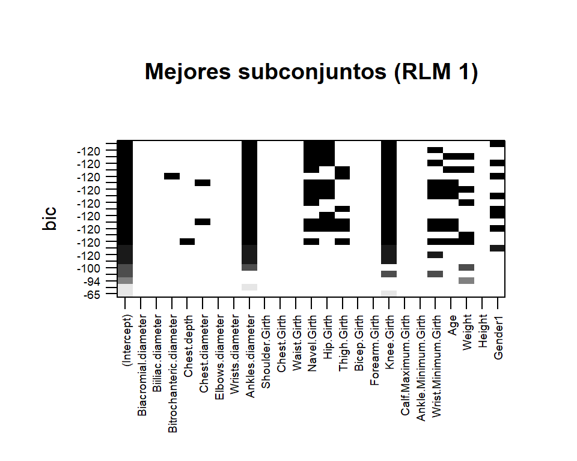

```r
respuesta_lineal <- "Knees.diameter"
respuesta_binaria <- "TRG"

rlm1_df <- muestra_ext |> select(-all_of(respuesta_binaria))
rlm1_fmla <- formula(paste(respuesta_lineal, ".", sep = " ~ "))
rlm1_sets <- regsubsets(rlm1_fmla, data = rlm1_df,
                        nbest = 3, nvmax = 8, method = "exhaustive")
rlm1_sets_summ <- summary(rlm1_sets)
rlm1_sets_i_mejor <- which.min(rlm1_sets_summ[["bic"]])
rlm1_seleccion <- names(which(rlm1_sets_summ[["which"]][rlm1_sets_i_mejor, ])[-1])

# Algunos ajustes gráficos para mejor visualización
par(cex.axis = 0.6, mgp = c(2.5, 0.75, 0))

plot(rlm1_sets, main = "Mejores subconjuntos (RLM 1)")
```

```r
cat("Mejores predictores para el modelo de RLM 1:\n")
print(rlm1_seleccion)
```

```
Mejores predictores para el modelo de RLM 1:
[1] "Ankles.diameter" "Navel.Girth"     "Hip.Girth"       "Knee.Girth"
[5] "Gender1"
```

Vemos que hay varios subconjuntos que llevan a un BIC de alrededor de $\small -120$. El mejor subconjunto considera una variable indicadora (`Gender1`) que en realidad no aparece en la matriz de datos. Debemos tener cuidado de cambiarla por el nombre verdadero antes de usar este conjunto para construir el modelo. Para ello usaremos la función `train()` del paquete caret, indicando que use bootstrapping con `B` repeticiones para evitar sobreajuste, teniendo cuidado de definir una semilla para poder reproducir el mismo resultado cada vez que se ejecute el código.

```r
rlm1_seleccion[5] <- "Gender"
rlm1_sel_text <- paste(rlm1_seleccion, collapse = " + ")
rlm1_fmla <- formula(paste(respuesta_lineal, rlm1_sel_text, sep = " ~ "))

B = 1999
set.seed(11 * 11111)
rlm1_train <- train(rlm1_fmla, data = rlm1_df, method = "lm",
                    trControl = trainControl(method = "boot", number = B))
rlm1 <- rlm1_train[["finalModel"]]

cat("Modelo de RLM 1:\n")
print(summary(rlm1))
```

```
Modelo de RLM 1:

Call:
lm(formula = .outcome ~ ., data = dat)

Residuals:
     Min       1Q   Median       3Q      Max
-1.38769 -0.28241 -0.04487  0.37080  1.49998

Coefficients:
                Estimate Std. Error t value Pr(>|t|)
(Intercept)      2.93227    1.13043   2.594 0.011006 *
Ankles.diameter  0.42012    0.08343   5.036 2.29e-06 ***
Navel.Girth     -0.03489    0.01191  -2.928 0.004274 **
Hip.Girth        0.07532    0.01890   3.985 0.000133 ***
Knee.Girth       0.15367    0.03934   3.906 0.000177 ***
Gender1          0.61814    0.17182   3.598 0.000514 ***
---
Signif. codes:  0 '***' 0.001 '**' 0.01 '*' 0.05 '.' 0.1 ' ' 1

Residual standard error: 0.6185 on 94 degrees of freedom
Multiple R-squared:  0.7815,    Adjusted R-squared:  0.7698
F-statistic: 67.23 on 5 and 94 DF,  p-value: < 2.2e-16
```

### Multicolinealidad

Cuando los modelos tienen muchos predictores, la probabilidad de que exista multicolinealidad aumenta. Por eso, es bueno que descartemos este potencial problema tempranamente.

```r
cat("Factores de inflación de la varianza:\n")
print(vif(rlm1))
cat("\n")
cat("Valores de tolerancia:\n")
print(1 / vif(rlm1))
```

```
Factores de inflación de la varianza:
Ankles.diameter     Navel.Girth       Hip.Girth      Knee.Girth         Gender1
       2.405305        2.787130        4.327124        2.699718        1.891284

Valores de tolerancia:
Ankles.diameter     Navel.Girth       Hip.Girth      Knee.Girth         Gender1
      0.4157478       0.3587920       0.2311004       0.3704091       0.5287412
```

Vemos que el predictor `Hip.Girth` está relativamente cerca del límite para declarar un problema de multicolinealidad. Para jugar seguro, mejor quitemos este predictor del modelo.

```r
rlm1_seleccion <- rlm1_seleccion[-3]
rlm1_sel_text <- paste(rlm1_seleccion, collapse = " + ")
rlm1_fmla <- formula(paste(respuesta_lineal, rlm1_sel_text, sep = " ~ "))

set.seed(11 * 11111)
rlm1_train <- train(rlm1_fmla, data = rlm1_df, method = "lm",
                    trControl = trainControl(method = "boot", number = B))
rlm1<- rlm1_train[["finalModel"]]

cat("Modelo de RLM 1 con cuatro predictores:\n")
print(summary(rlm1))
```

```
Modelo de RLM 1 con cuatro predictores:

Call:
lm(formula = .outcome ~ ., data = dat)

Residuals:
    Min      1Q  Median      3Q     Max
-1.4967 -0.3223  0.0071  0.3946  2.3309

Coefficients:
                 Estimate Std. Error t value Pr(>|t|)
(Intercept)      3.985153   1.182097   3.371  0.00108 **
Ankles.diameter  0.428360   0.089700   4.775 6.50e-06 ***
Navel.Girth     -0.005373   0.010037  -0.535  0.59365
Knee.Girth       0.255146   0.032258   7.909 4.67e-12 ***
Gender1          0.497535   0.181896   2.735  0.00744 **
---
Signif. codes:  0 '***' 0.001 '**' 0.01 '*' 0.05 '.' 0.1 ' ' 1

Residual standard error: 0.6652 on 95 degrees of freedom
Multiple R-squared:  0.7445,    Adjusted R-squared:  0.7338
F-statistic: 69.22 on 4 and 95 DF,  p-value: < 2.2e-16
```

¡Oh! Al quitar el predictor `Hip.Girth`, sin intención, el predictor `Navel.Girth` se volvió irrelevante para el modelo. Basados en el principio de parsimonia, quitemos también esta variable del modelo.

```r
rlm1_seleccion <- rlm1_seleccion[-2]
rlm1_sel_text <- paste(rlm1_seleccion, collapse = " + ")
rlm1_fmla <- formula(paste(respuesta_lineal, rlm1_sel_text, sep = " ~ "))

set.seed(11 * 11111)
rlm1_train <- train(rlm1_fmla, data = rlm1_df, method = "lm",
                    trControl = trainControl(method = "boot", number = B))
rlm1<- rlm1_train[["finalModel"]]

cat("Modelo de RLM 1 con cuatro predictores:\n")
print(summary(rlm1))
```

```
Modelo de RLM 1 con cuatro predictores:

Call:
lm(formula = .outcome ~ ., data = dat)

Residuals:
     Min       1Q   Median       3Q      Max
-1.50091 -0.33368 -0.01754  0.39685  2.32994

Coefficients:
                Estimate Std. Error t value Pr(>|t|)
(Intercept)      4.02955    1.17480   3.430 0.000891 ***
Ankles.diameter  0.41122    0.08348   4.926 3.50e-06 ***
Knee.Girth       0.24762    0.02893   8.560 1.83e-13 ***
Gender1          0.51249    0.17907   2.862 0.005169 **
---
Signif. codes:  0 '***' 0.001 '**' 0.01 '*' 0.05 '.' 0.1 ' ' 1

Residual standard error: 0.6627 on 96 degrees of freedom
Multiple R-squared:  0.7438,    Adjusted R-squared:  0.7358
F-statistic: 92.88 on 3 and 96 DF,  p-value: < 2.2e-16
```

¡Bien! Se tiene un modelo con 3 predictores que aportan significativamente a su ajuste.

Verifiquemos entonces la multicolinealidad de este modelo más reducido.

```r
cat("Factores de inflación de la varianza:\n")
print(vif(rlm1))
cat("\n")
cat("Valores de tolerancia:\n")
print(1 / vif(rlm1))
```

```
Factores de inflación de la varianza:
Ankles.diameter      Knee.Girth         Gender1
       2.097691        1.271088        1.789416

Valores de tolerancia:
Ankles.diameter      Knee.Girth         Gender1
      0.4767147       0.7867278       0.5588414
```

¡Bien! Ahora el modelo presenta niveles de multicolinealidad aceptables.

### Ajuste, linealidad, normalidad y homocedasticidad

En la salida a pantalla anterior, podemos observar que el modelo obtenido consigue una reducción significativa de la varianza no explicada ($\small F(3, 96)=92{,}88$; $\small p\ll0{,}001$) respecto del modelo nulo.

Comprobemos ahora que los residuos cumplen las condiciones necesarias usando la función `residualPlots()` del paquete `car`. Sin embargo, las funciones de este paquete tienen problemas encontrando información usada por la función `train()` del paquete `caret` en la construcción del modelo. Por esta razón, primero creamos un modelo de la manera tradicional que es **equivalente** al modelo final obtenido por `train()`.

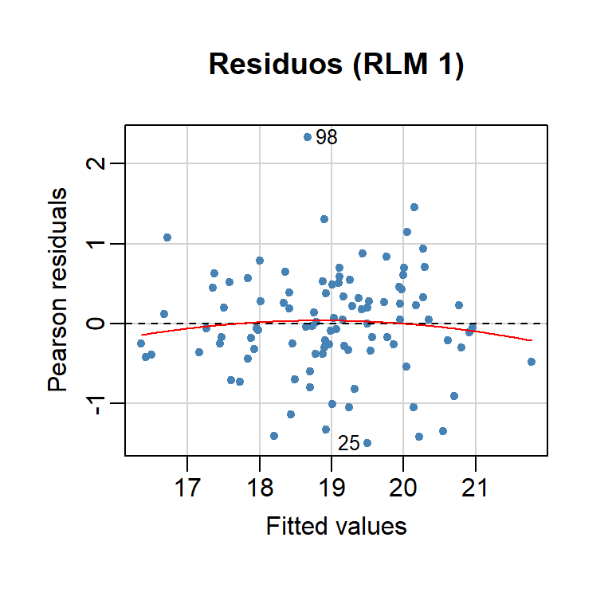

```
Prueba de curvatura para los predictores del modelo de RLM 1:
           Test stat Pr(>|Test stat|)
Tukey test    -0.741           0.4587
```

```r
rlm1_equiv <- lm(rlm1_fmla, rlm1_df)

par(mgp = c(1.75, 0.5, 0))
cat("Prueba de curvatura para los predictores del modelo de RLM 1:\n")
residualPlots(rlm1_equiv, terms = ~ 1,
              col = "steelblue", pch = 20, col.quad = "red",
              id = list(cex = 0.8, location = "lr"))
title("Residuos (RLM 1)")
```

Vemos que, si bien hay un caso atípico (con etiqueta “98”), no se observan patrones problemáticos, lo que es confirmado por las pruebas de curvatura aplicadas ($\small Z=-0{,}741$; $\small p=0{,}459$). Así, no hay evidencia para sospechar que los residuos no siguen una distribución normal centrada en cero para cada predictor (aunque se ven algunos posibles valores atípicos).

Revisemos que la variable de salida se relaciona linealmente con los predictores por medio del gráfico de residuos parciales que entrega la función `crPlots()` del paquete `car`.

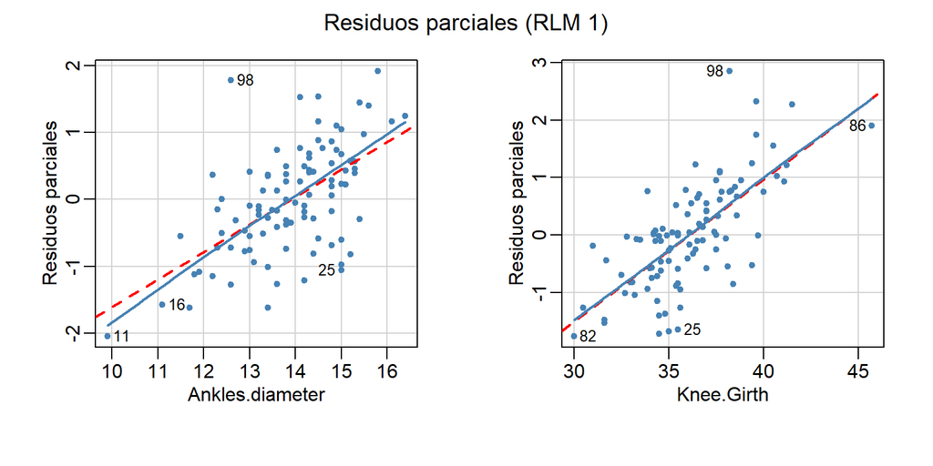

```r
par(mgp = c(1.5, 0.5, 0))
crPlots(rlm1_equiv, terms = ~ . - Gender, layout = c(1, 2),
        col = "steelblue", pch = 20, col.lines = c("red", "steelblue"),
        smooth = list(smoother = loessLine, span = 1),
        id = list(cex = 0.8, location = "lr"),
        main = "Residuos parciales (RLM 1)", ylab = "Residuos parciales")
```

Primero, notamos que las relaciones entre cada predictor y la variable respuesta son aproximadamente lineales. Segundo, el modelo (línea segmentada roja) se ajusta bien a las relaciones observadas (líneas continua azul-acero), con unas leves desviaciones en los datos más extremos que evita apalancamiento de un par de casos extremos en la variable `Ankles.diameter`.

Tampoco se ven cambios en notorios en la varianza, lo que podemos confirmar con la prueba de varianza del error no constante.

```r
cat("Prueba de varianza del error no constante:\n")
ncvTest(rlm1_equiv)
```

```
Prueba de varianza del error no constante:
Non-constant Variance Score Test
Variance formula: ~ fitted.values
Chisquare = 0.8843718, Df = 1, p = 0.34701
```

### Casos sobreinfluyentes

Usemos el gráfico de diagnóstico disponible en el paquete `car` entregado por la función `influencePlot()` que ya hemos usado en ejercicios prácticos anteriores.

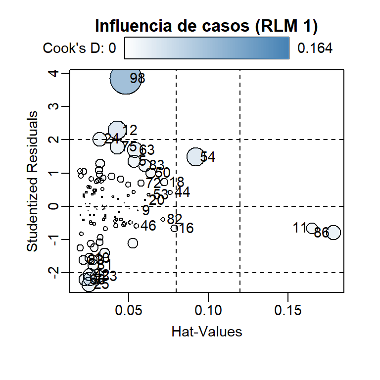

```r
par(cex = 0.9, mgp = c(1.75, 0.5, 0))
rlm1_inf <- influencePlot(rlm1_equiv, fill.col = "steelblue",
           ,              scale = 5, id = list(n = 15),
                          main = "Influencia de casos (RLM 1)\n")
```

Ahora determinemos los umbrales a considerar.

```r
n_casos1 <- nrow(rlm1_df)          # Número de casos
p_rlm1 <- length(coef(rlm1))       # Número de parámetros del modelo
gdl_rlm1 <- n_casos1 - p_rlm1 - 1  # Grados de libertad del modelo

lim_res_rlm1 <- abs(round(qt(0.05 / 2, df = gdl_rlm1), 3))
lim_hat_rlm1 <- round(2 * mean(hatvalues(rlm1)), 3)
lim_cook1_rlm1 <- round(mean(cooks.distance(rlm1)) +
                             3 * sd(cooks.distance(rlm1)), 3)
lim_cook2_rlm1 <- round(qf(0.5, df1 = p_rlm1, df2 = n_casos1 - p_rlm1), 3)

cat("Límites para el modelo de RLM 1:\n")
cat("Rango para 95% de los residuos studentizados: ")
cat("[", -lim_res_rlm1, ", ", lim_res_rlm1, "]\n", sep = "")
cat("Límite del apalancamiento:", lim_hat_rlm1, "\n")
cat("Límite de sospecha para la distancia de Cook:", lim_cook1_rlm1, "\n")
cat("Límite crítico para la distancia de Cook:", lim_cook2_rlm1, "\n")
```

```
Límites para el modelo de RLM 1:
Rango para 95% de los residuos studentizados: [-1.985, 1.985]
Límite del apalancamiento: 0.08
Límite de sospecha para la distancia de Cook: 0.069
Límite crítico para la distancia de Cook: 0.845
```

Listemos los casos notorios que sobrepasan estos límites.

```r
rlm1_inf_filtrados <- rlm1_inf |>
  filter(abs(StudRes) > lim_res_rlm1 |
         Hat > lim_hat_rlm1 |
         CookD > lim_cook1_rlm1)

cat("Casos notorios para el modelo de regresión logística múltiple:\n")
print(rlm1_inf_filtrados)
```

```
Casos notorios para el modelo de regresión logística múltiple:
      StudRes        Hat      CookD
7  -2.1927233 0.02585717 0.03068823
11 -0.6503370 0.16516042 0.02104449
12  2.2917453 0.04300738 0.05650473
24  2.0268870 0.03175370 0.03262638
25 -2.3471395 0.02526730 0.03410021
33 -2.1034151 0.03030637 0.03337858
42 -2.0581811 0.02561318 0.02693028
54  1.4844392 0.09229999 0.05532396
68 -2.2092545 0.02274065 0.02729064
86 -0.7975889 0.17885200 0.03477120
98  3.8547262 0.04810976 0.16406248
```

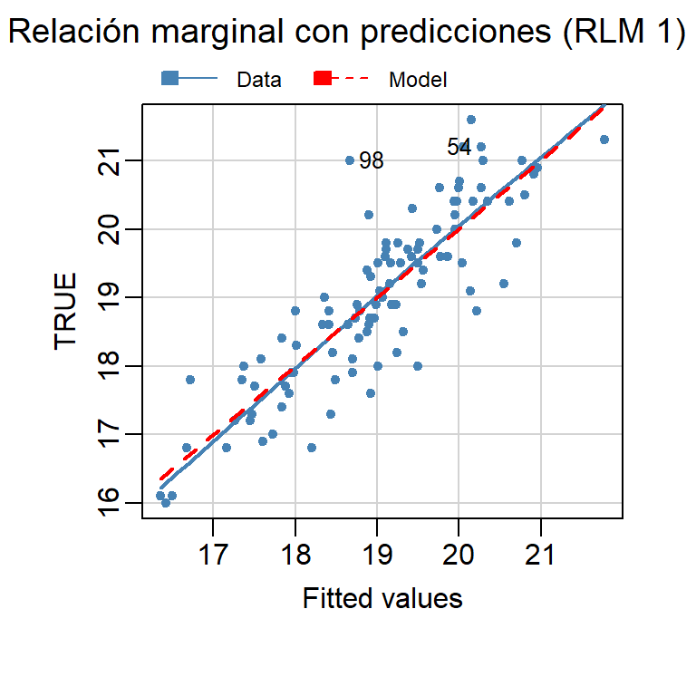

```r
casos <- rownames(rlm1_inf_filtrados)
id_casos <- which(casos == "54" | casos == "98")

par(mgp = c(1.75, 0.5, 0))
mmps(rlm1_equiv, terms = ~ 1,
     col = "steelblue", pch = 20, col.line = c("steelblue", "red"),
     smooth = list(smoother = loessLine, span = 1),
     id = list(method = casos[id_casos], cex = 0.8, location = "lr"),
     main = "Relación marginal con predicciones (RLM 1)", sub = " ")
```

Podemos ver, en esta figura y en los gráficos de residuos parciales, que ninguno de los casos potencialmente problemáticos distorsiona notoriamente la línea del modelo, por lo que no es necesario eliminar ninguna de estas observaciones.

### Independencia de los residuos

Confirmemos que no existe dependencia entre los residuos generados por el modelo de RLM 1.

```r
cat("Prueba de la independencia de los residuos para el modelo de RLM 1:\n")
print(durbinWatsonTest(rlm1))
```

```
Prueba de la independencia de los residuos para el modelo de RLM 1:
 lag Autocorrelation D-W Statistic p-value
   1      -0.0126973      2.002099   0.998
 Alternative hypothesis: rho != 0
```

Vemos que no hay razones para sospechar que los residuos no sean independientes para este modelo ($\small \text{D-W}=2{,}002$; $\small p=0{,}998$).

### Desempeño

Veamos los niveles de error cometidos por el modelo de RLM 1 que hemos conseguido, analizando un histograma de los errores (RMSE) en cada repetición del bootstrapping y el reporte del error promedio generado por la función `train()`.

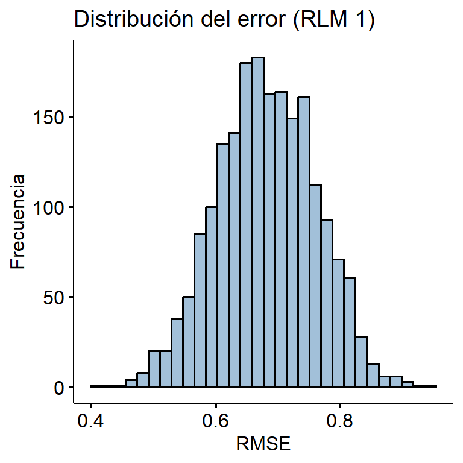

```r
rlm1_err_df <- data.frame(RMSE = rlm1_train[["resample"]][["RMSE"]])
rlm1_err_p <- gghistogram(rlm1_err_df, x = "RMSE", bins = 30,
                          fill = "steelblue", ylab = "Frecuencia",
                          title = "Distribución del error (RLM 1)")
print(rlm1_err_p)
```

```r
cat("Rendimiento del modelo de RLM 1:\n")
print(rlm1_train[["results"]], digits = 3)
cat("\nMás detalle del raíz del error cuadrático medio:\n")
print(describe(rlm1_err_df, trim = 0, quant = c(0.25, 0.75),
               skew = FALSE, IQR = TRUE), digits = 3)
```

```
Rendimiento del modelo de RLM 1:
  intercept  RMSE Rsquared   MAE RMSESD RsquaredSD  MAESD
1      TRUE 0.681    0.728 0.525 0.0797      0.073 0.0605

Más detalle del raíz del error cuadrático medio:
     vars    n  mean   sd median   min   max range    se   IQR Q0.25 Q0.75
RMSE    1 1999 0.681 0.08  0.681 0.409 0.944 0.536 0.002 0.113 0.625 0.738
```

## Regresión lineal múltiple usando Recursive Feature Elimination

El paquete `caret` implementa la *regresión escalonada hacia atrás* bajo el nombre de Recursive Feature Elimination (RFE), mediante la función `rfe()`. Se pueden definir varias alternativas de control para guíar la búsqueda, incluyendo funciones *wrapper* para varios tipos de modelo. En particular, `caret` proporciona la función *wrapper* `lmFuncs` para trabajar modelos de regresión lineal.

La instrucción 4 nos indica buscar, mediante cinco repeticiones de validación cruzada de cinco pliegues, un modelo de RLM que consiga el mayor valor del coeficiente de determinación $\small R^{2}$ y que incluya entre 5 y 15 predictores. Esto podemos hacerlo con el siguiente código. Como la validación cruzada divide los datos de forma aleatoria, vamos a tener el cuidado de definir una semilla para su reproducibilidad.

```r
rlm2_df <- muestra_ext |> select(-all_of(respuesta_binaria))
rlm2_fmla <- formula(paste(respuesta_lineal, ".", sep = " ~ "))
rlm2_control <- rfeControl(functions = lmFuncs, method = "repeatedcv",
                           number = 5, repeats = 5, verbose = FALSE)

set.seed(13 * 11111)
rlm2_rfe <- rfe(rlm2_fmla, data = rlm2_df, rfeControl = rlm2_control,
                sizes = 5:15, metric = "Rsquared")
rlm2 <- rlm2_rfe[["fit"]]
```

Veamos una representación gráfica del proceso de búsqueda realizado.

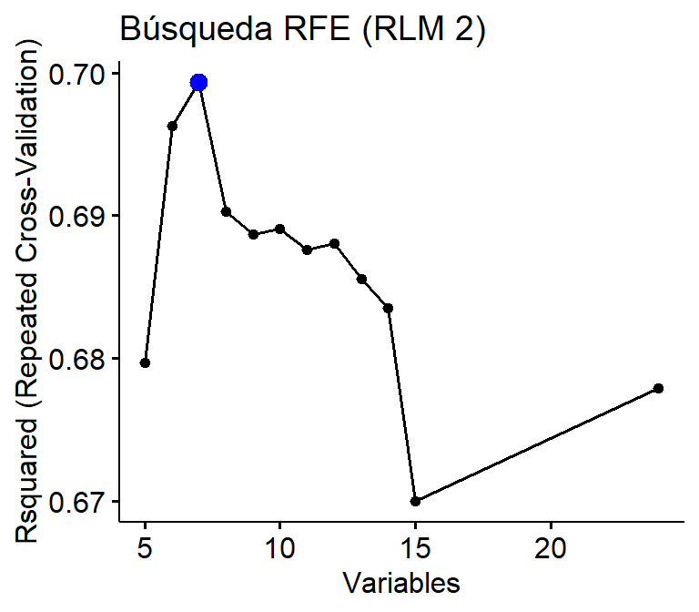

```r
rlm2_rfe_p <- ggplot(rlm2_rfe) + theme_pubr()
rlm2_rfe_p <- ggpar(rlm2_rfe_p, title = "Búsqueda RFE (RLM 2)")
print(rlm2_rfe_p)
```

Podemos apreciar que la búsqueda obtuvo el valor del $\small R^{2}$ más alto con un modelo que considera 7 variables. Veamos el modelo obtenido.

```r
cat("Modelo de RLM 2 obtenido con RFE:\n")
print(summary(rlm2))
```

```
Modelo de RLM 2 obtenido con RFE:

Call:
lm(formula = y ~ ., data = tmp)

Residuals:
     Min       1Q   Median       3Q      Max
-2.09011 -0.57630 -0.02443  0.50732  3.01450

Coefficients:
                    Estimate Std. Error t value Pr(>|t|)
(Intercept)          5.29544    1.64110   3.227 0.001735 **
Gender1             -0.33824    0.30246  -1.118 0.266355
Wrist.Minimum.Girth  0.15075    0.15929   0.946 0.346440
Ankles.diameter      0.43945    0.12635   3.478 0.000773 ***
Wrists.diameter      0.05675    0.21346   0.266 0.790929
Elbows.diameter      0.03287    0.13747   0.239 0.811555
Chest.depth          0.04839    0.05063   0.956 0.341794
Forearm.Girth        0.12670    0.07477   1.695 0.093544 .
---
Signif. codes:  0 '***' 0.001 '**' 0.01 '*' 0.05 '.' 0.1 ' ' 1

Residual standard error: 0.8204 on 92 degrees of freedom
Multiple R-squared:  0.6237,    Adjusted R-squared:  0.595
F-statistic: 21.78 on 7 and 92 DF,  p-value: < 2.2e-16
```

### Multicolinealidad

Revisemos los niveles de multicolinealidad del modelo obtenido.

```r
cat("Factores de inflación de la varianza:\n")
print(vif(rlm2))
cat("\n")
cat("Valores de tolerancia:\n")
print(1 / vif(rlm2))
```

```
Factores de inflación de la varianza:
            Gender1 Wrist.Minimum.Girth     Ankles.diameter     Wrists.diameter
           3.330997            6.796051            3.135140            5.706823
    Elbows.diameter         Chest.depth       Forearm.Girth
           4.820786            2.189152            6.295889

Valores de tolerancia:
            Gender1 Wrist.Minimum.Girth     Ankles.diameter     Wrists.diameter
          0.3002104           0.1471443           0.3189651           0.1752288
    Elbows.diameter         Chest.depth       Forearm.Girth
          0.2074350           0.4567980           0.1588338
```

Vemos que hay varios predictores con valores de inflación de la varianza cercanos o sobre $\small 5$. La variable `Wrist.Minimum.Girth` es la que presenta el valor más alto, por lo que es mejor quitarla del modelo.

```r
rlm2_seleccion <- predictors(rlm2)[-2]
rlm2_seleccion[1] <- "Gender"
rlm2_sel_text <- paste(rlm2_seleccion, collapse = " + ")
rlm2_fmla <- formula(paste(respuesta_lineal, rlm2_sel_text, sep = " ~ "))

set.seed(13 * 11111)
rlm2_train <- train(rlm2_fmla, data = rlm2_df, method = "lm",
                    trControl = trainControl(method = "repeatedcv", number = 5, repeats = 5))
rlm2<- rlm2_train[["finalModel"]]

cat("Nuevos factores de inflación de la varianza:\n")
print(vif(rlm2))
cat("\n")
cat("Nuevos valores de tolerancia:\n")
print(1 / vif(rlm2))
```

```
Nuevos factores de inflación de la varianza:
        Gender1 Ankles.diameter Wrists.diameter Elbows.diameter     Chest.depth
       3.329586        3.099705        4.519014        4.819889        2.153033
  Forearm.Girth
       4.884168

Nuevos valores de tolerancia:
        Gender1 Ankles.diameter Wrists.diameter Elbows.diameter     Chest.depth
      0.3003376       0.3226114       0.2212872       0.2074737       0.4644610
  Forearm.Girth
      0.2047432
```

Podemos apreciar que mejoran los valores de inflación de la varianza, aunque la variable `Forearm.Girth` sigue presentando un valor alto. Mejor quitarla del modelo.

```r
rlm2_seleccion <- rlm2_seleccion[-6]
rlm2_sel_text <- paste(rlm2_seleccion, collapse = " + ")
rlm2_fmla <- formula(paste(respuesta_lineal, rlm2_sel_text, sep = " ~ "))

set.seed(13 * 11111)
rlm2_train <- train(rlm2_fmla, data = rlm2_df, method = "lm",
                    trControl = trainControl(method = "repeatedcv", number = 5, repeats = 5))
rlm2 <- rlm2_train[["finalModel"]]

cat("Nuevos factores de inflación de la varianza (2):\n")
print(vif(rlm2))
cat("\n")
cat("Nuevos valores de tolerancia (2):\n")
print(1 / vif(rlm2))
```

```
Nuevos factores de inflación de la varianza (2):
        Gender1 Ankles.diameter Wrists.diameter Elbows.diameter     Chest.depth
       3.200859        3.094765        4.053677        4.168391        1.987696

Nuevos valores de tolerancia (2):
        Gender1 Ankles.diameter Wrists.diameter Elbows.diameter     Chest.depth
      0.3124161       0.3231263       0.2466896       0.2399007       0.5030950
```

Vemos que ahora los predictores presentan niveles de multicolinealidad más o menos aceptables. Como el enunciado nos exige un mínimo de 5 predictores, detenemos esta poda aquí, aunque es probable que todavía haya espacio para reducir el modelo.

### Ajuste y linealidad

Revisemos el modelo conseguido.

```r
cat("Modelo de RLM 2 con cinco predictores:\n")
print(summary(rlm2), digits = 3)
```

```
Modelo de RLM 2 con cinco predictores:

Call:
lm(formula = .outcome ~ ., data = dat)

Residuals:
   Min     1Q Median     3Q    Max
-2.004 -0.502 -0.026  0.519  3.174

Coefficients:
                Estimate Std. Error t value Pr(>|t|)
(Intercept)       6.0237     1.6372    3.68  0.00039 ***
Gender1          -0.1995     0.3040   -0.66  0.51329
Ankles.diameter   0.4400     0.1287    3.42  0.00093 ***
Wrists.diameter   0.2972     0.1845    1.61  0.11048
Elbows.diameter   0.1540     0.1311    1.18  0.24285
Chest.depth       0.0884     0.0495    1.79  0.07719 .
---
Signif. codes:  0 '***' 0.001 '**' 0.01 '*' 0.05 '.' 0.1 ' ' 1

Residual standard error: 0.841 on 94 degrees of freedom
Multiple R-squared:  0.596, Adjusted R-squared:  0.574
F-statistic: 27.7 on 5 and 94 DF,  p-value: <2e-16
```

Observamos que el modelo consigue una reducción significa de la varianza no explicada en comparación al modelo nulo ($\small F(5, 94)=27{,}7$; $\small p<0{,}001$), aunque confirmamos que hay variables que no contribuyen significativamente a este ajuste y que podrían quitarse del modelo.

Revisemos el gráfico de diagnóstico de los residuos que genera este modelo (usando un modelo equivalente creado con las funciones base).

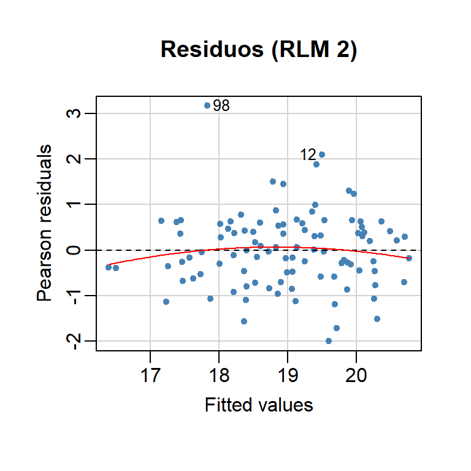

```
Prueba de curvatura para los predictores del modelo de RLM 2:
           Test stat Pr(>|Test stat|)
Tukey test   -0.9153             0.36
```

```r
rlm2_equiv <- lm(rlm2_fmla, rlm2_df)

par(mgp = c(1.75, 0.5, 0))
cat("Prueba de curvatura para los predictores del modelo de RLM 2:\n")
residualPlots(rlm2_equiv, terms = ~ 1,
              col = "steelblue", pch = 20, col.quad = "red",
              id = list(cex = 0.8, location = "lr"))
title("Residuos (RLM 2)")
```

Vemos que los residuos muestran el comportamiento esperado, con el mismo caso atípico observado con el modelo anterior. Esto es confirmado por la prueba de curvatura, por lo que no tenemos evidencia para creer que los residuos no siguen una distribución normal con varianza constante. Si tuviéramos dudas, podríamos confirmar con gráficos y pruebas auxiliares.

```r
cat("Normalidad de los residuos generados por el modelo (RLM 2):\n")
shapiro.test(resid(rlm2))

cat("\nPrueba de varianza del error no constante (RLM 2):\n")
ncvTest(rlm2)
```

```
Normalidad de los residuos generados por el modelo (RLM 2):

    Shapiro-Wilk normality test

data:  resid(rlm2)
W = 0.9714, p-value = 0.02834


Prueba de varianza del error no constante (RLM 2):
Non-constant Variance Score Test
Variance formula: ~ fitted.values
Chisquare = 0.04152027, Df = 1, p = 0.83854
```

¡Oh! La prueba auxiliar rechaza la idea de que los residuos siguen una distribución normal. Pero esto podría ser efecto del (¿único?) caso atípico 98. Verifiquemos esta hipótesis.

```r
cat("Normalidad de los residuos sin el caso atípico (RLM 2):\n")
shapiro.test(resid(rlm2)[-98])
```

```
Normalidad de los residuos sin el caso atípico (RLM 2):

    Shapiro-Wilk normality test

data:  resid(rlm2)[-98]
W = 0.98996, p-value = 0.6677
```

Confirmamos que el caso 98 es el responsable de que la prueba de normalidad para los residuos del modelo resulte significativa. Pongamos atención en este valor, pues podría estar afectando la confiabilidad del modelo y ser necesario eliminarlo.

Revisemos ahora la condición de linealidad entre predictores y variable de salida.

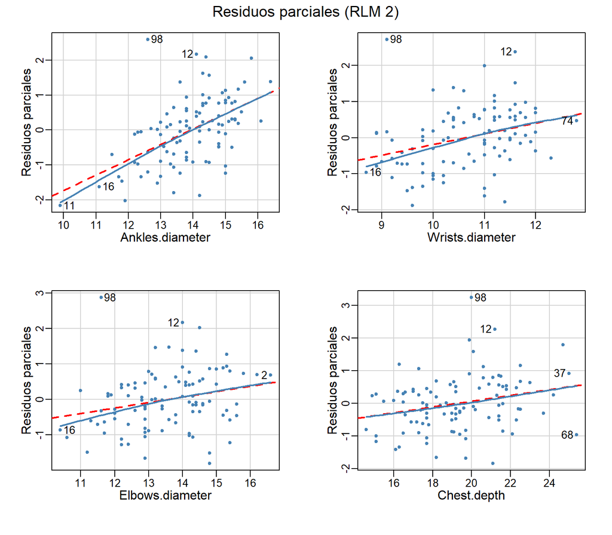

```r
par(cex.lab = 1.2, mgp = c(1.5, 0.5, 0))
crPlots(rlm2_equiv, terms = ~ . - Gender,
        col = "steelblue", pch = 20, col.lines = c("red", "steelblue"),
        smooth = list(smoother = loessLine, span = 1),
        id = list(cex = 1.0, location = "lr"),
        main = "Residuos parciales (RLM 2)", ylab = "Residuos parciales")
```

Observamos que las relaciones entre cada predictor y la variable respuesta son aproximadamente lineales y que el modelo logra ajustarse bien a estos datos, con desviaciones leves en el extremo inferior de estas variables.

### Casos sobreinfluyentes

Revisemos el gráfico de influencia y los casos notorios que se identifican en él.

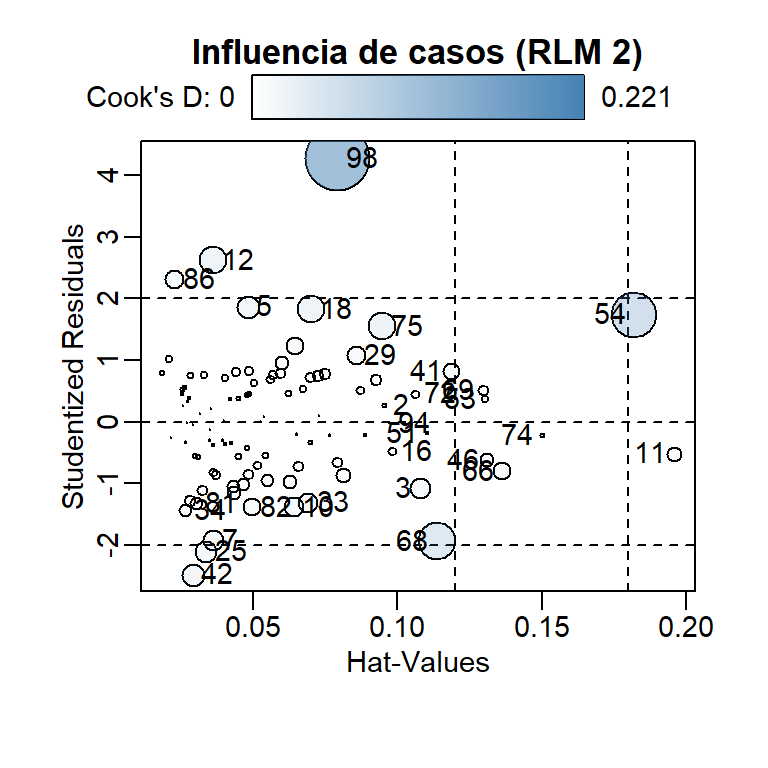

```r
par(cex = 0.9, mgp = c(1.5, 0.5, 0))
rlm2_inf <- influencePlot(rlm2_equiv, fill.col = "steelblue",
                          scale = 5, id = list(n = 15),
                          main = "Influencia de casos (RLM 2)\n")
```

Ahora determinemos los umbrales a considerar para este modelo.

```r
n_casos2 <- nrow(rlm2_df)           # Número de casos
p_rlm2 <- length(coef(rlm2))        # Número de parámetros del modelo
gdl_rlm2 <- n_casos2 - p_rlm2 - 1   # Grados de libertad del modelo

lim_res_rlm2 <- abs(round(qt(0.05 / 2, df = gdl_rlm2), 3))
lim_hat_rlm2 <- round(2 * mean(hatvalues(rlm2)), 3)
lim_cook1_rlm2 <- round(mean(cooks.distance(rlm2)) +
                        3 * sd(cooks.distance(rlm2)), 3)
lim_cook2_rlm2 <- round(qf(0.5, df1 = p_rlm2, df2 = n_casos2 - p_rlm2), 3)

cat("Límites para el modelo de RLM 2:\n")
cat("Rango para 95% de los residuos studentizados: ")
cat("[", -lim_res_rlm2, ", ", lim_res_rlm2, "]\n", sep = "")
cat("Límite del apalancamiento:", lim_hat_rlm2, "\n")
cat("Límite de sospecha para la distancia de Cook:", lim_cook1_rlm2, "\n")
cat("Límite crítico para la distancia de Cook:", lim_cook2_rlm2, "\n")
```

```
Límites para el modelo de RLM 2:
Rango para 95% de los residuos studentizados: [-1.986, 1.986]
Límite del apalancamiento: 0.12
Límite de sospecha para la distancia de Cook: 0.09
Límite crítico para la distancia de Cook: 0.898
```

Revisemos los casos notorios que sobrepasan estos límites.

```r
rlm2_inf_filtrados <- rlm2_inf |>
  filter(abs(StudRes) > lim_res_rlm2 |
         Hat > lim_hat_rlm2 |
         CookD > lim_cook1_rlm2)

cat("Casos notorios para el modelo de regresión logística múltiple:\n")
print(rlm2_inf_filtrados)
```

```
Casos notorios para el modelo de regresión logística múltiple:
      StudRes        Hat       CookD
11 -0.5208844 0.19601905 0.011111271
12  2.6135436 0.03608069 0.040124218
25 -2.1102342 0.03364057 0.024921090
42 -2.4837976 0.02898390 0.029091246
46 -0.6270884 0.13116350 0.009958494
53  0.3679664 0.13025334 0.003410941
54  1.7361259 0.18209073 0.109493062
66 -0.7986042 0.13630393 0.016839771
69  0.5048214 0.12961672 0.006375748
74 -0.2233511 0.15007108 0.001483035
86  2.3107333 0.02269090 0.019750040
98  4.2782016 0.07913052 0.221379876
```

A priori, ningún residuo esta fuera de rango en los tres criterios. El caso 54 presenta apalancamiento y distancia de Cook fuera de los límites, pero el caso atípico 98 es el que presenta la mayor distancia de Cook. Veamos el impacto de este último en las predicciones del modelo.

```r
casos <- rownames(rlm2_inf_filtrados)
id_casos <- which(casos == "98")
i_datos <- which(rownames(rlm2_df) %in% casos[id_casos])

rlm2a <- update(rlm2_equiv, data = rlm2_df[-i_datos, ])

par(mgp = c(1.5, 0.5, 0), mfrow = c(1, 2))
invisible(mmp(rlm2_equiv,
          col = "steelblue", pch = 20, col.line = c("steelblue", "red"),
          smooth = list(smoother = loessLine, span = 1),
          id = list(method = casos[id_casos], cex = 0.8, location = "lr"),
          main = "Relación marginal (RLM 2)")
)
invisible(mmp(rlm2a,
          col = "steelblue", pch = 20, col.line = c("steelblue", "red"),
          smooth = list(smoother = loessLine, span = 1),
          id = list(n = 3, location = "lr", cex = 0.8),
          main = "Relación marginal (RLM 2a)")
)
```

[figure not shown]

Podemos observar que el caso 98 en realidad parece apalancar el extremo inferior del modelo. Como ejercicio académico, asumiremos que es mejor eliminar este caso atípico para conseguir un modelo que se ajuste mejor a la mayoría de los datos.

### Modelo de RLM 2a

#### Nuevo ajuste

Procedamos a reentrenar el modelo sin el caso 98.

```r
i <- which(rownames(rlm2_df) == "98")
rlm2a_df <- rlm2_df[-i, ]

set.seed(13 * 11111)
rlm2a_train <- train(rlm2_fmla, data = rlm2a_df, method = "lm",
                          trControl = trainControl(method = "repeatedcv", number = 5, repeats = 5))
rlm2a <- rlm2a_train[["finalModel"]]

cat("Modelo de RLM 2 alyternativo con cinco predictores:\n")
print(summary(rlm2a), digits = 3)
```

```
Modelo de RLM 2 alyternativo con cinco predictores:

Call:
lm(formula = .outcome ~ ., data = dat)

Residuals:
    Min      1Q  Median      3Q     Max
-2.0199 -0.4878  0.0373  0.5206  2.0976

Coefficients:
                Estimate Std. Error t value Pr(>|t|)
(Intercept)       5.3336     1.5132    3.52  0.00066 ***
Gender1          -0.2048     0.2794   -0.73  0.46526
Ankles.diameter   0.4268     0.1183    3.61  0.00050 ***
Wrists.diameter   0.3921     0.1710    2.29  0.02408 *
Elbows.diameter   0.1976     0.1209    1.64  0.10542
Chest.depth       0.0491     0.0464    1.06  0.29269
---
Signif. codes:  0 '***' 0.001 '**' 0.01 '*' 0.05 '.' 0.1 ' ' 1

Residual standard error: 0.773 on 93 degrees of freedom
Multiple R-squared:  0.654, Adjusted R-squared:  0.635
F-statistic: 35.1 on 5 and 93 DF,  p-value: <2e-16
```

Vemos que en este nuevo modelo presenta un ajuste general un poco mejor ($\small F(5, 93)=35{,}10$; $\small p<0{,}001$) y ahora la variable `Wrists.diameter` aporta significativamente a la reducción de la varianza conseguida ($\small t(93)=2{,}29$; $\small p=0{,}024$). Debe notarse que hemos fijado la misma semilla que usamos al realizar la búsqueda con la función `rfe()` para conseguir pliegues y repeticiones (idealmente) equivalentes.

#### Reevaluación de la multicolinealidad.

Verificamos que seguimos sin problemas de colinealidad.

```r
cat("Nuevos factores de inflación de la varianza (2):\n")
print(vif(rlm2a))
cat("\n")
cat("Nuevos valores de tolerancia (2):\n")
print(1 / vif(rlm2a))
```

```
Nuevos factores de inflación de la varianza (2):
        Gender1 Ankles.diameter Wrists.diameter Elbows.diameter     Chest.depth
       3.158064        3.055620        4.005584        4.106822        2.066994

Nuevos valores de tolerancia (2):
        Gender1 Ankles.diameter Wrists.diameter Elbows.diameter     Chest.depth
      0.3166497       0.3272658       0.2496515       0.2434973       0.4837944
```

Seguimos con valores aceptables, similares a los que teníamos.

#### Reevaluación de los residuos.

Revisemos los residuos nuevamente.

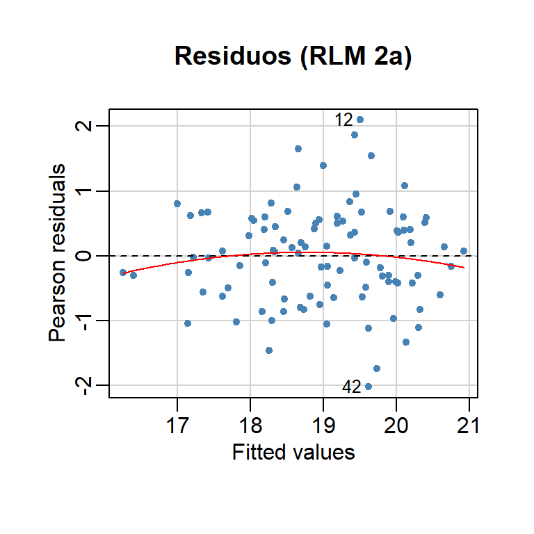

```
Prueba de curvatura para el modelo de RLM 2 alternativo:
           Test stat Pr(>|Test stat|)
Tukey test   -0.8275           0.4079
```

```r
rlm2a_equiv <- lm(rlm2_fmla, rlm2a_df)

par(mgp = c(1.5, 0.5, 0))
cat("Prueba de curvatura para el modelo de RLM 2 alternativo:\n")
residualPlots(rlm2a_equiv, terms = ~ 1,
              col = "steelblue", pch = 20, col.quad = "red",
              id = list(cex = 0.8, location = "lr"))
title("Residuos (RLM 2a)")
```

Bien, los residuos del modelo nuevo muestran el comportamiento esperado, que podemos confirmar con las pruebas auxiliares.

```r
cat("Normalidad de los residuos generados por el modelo (RLM 2 alternativo):\n")
shapiro.test(resid(rlm2a))

cat("\nPrueba de varianza del error no constante (RLM 2 alternativo):\n")
ncvTest(rlm2a)
```

```
Normalidad de los residuos generados por el modelo (RLM 2 alternativo):

    Shapiro-Wilk normality test

data:  resid(rlm2a)
W = 0.99051, p-value = 0.7124


Prueba de varianza del error no constante (RLM 2 alternativo):
Non-constant Variance Score Test
Variance formula: ~ fitted.values
Chisquare = 1.249867, Df = 1, p = 0.26358
```

Confirmamos que no hay evidencia de problemas con la normalidad ni homocedasticidad de los residuos del nuevo modelo.

#### Reevaluación de la condición de linealidad.

Volvemos a revisar la condición de linealidad entre predictores y variable de salida.

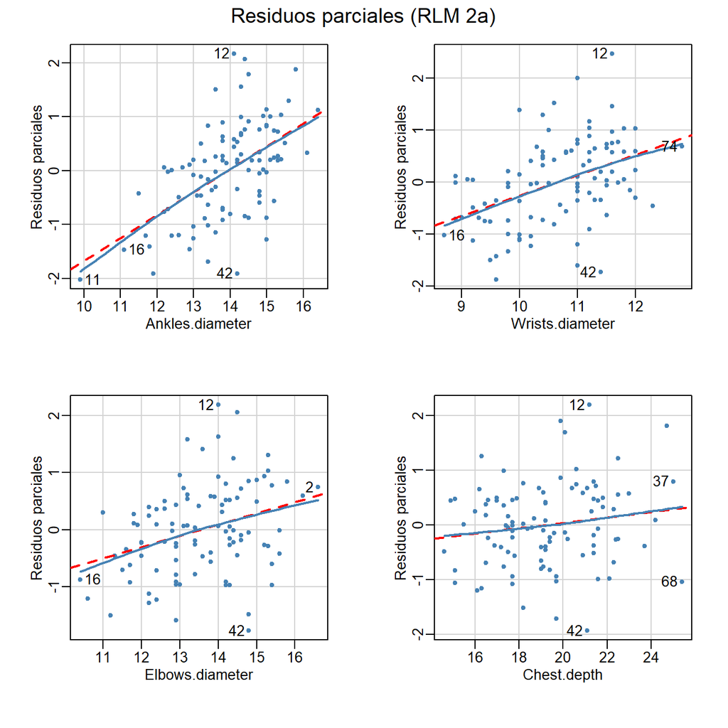

```r
par(mgp = c(1.5, 0.5, 0))
crPlots(rlm2a_equiv, terms = ~ . - Gender,
        col = "steelblue", pch = 20, col.lines = c("red", "steelblue"),
        smooth = list(smoother = loessLine, span = 1),
        id = list(cex = 1.0, location = "lr"),
        main = "Residuos parciales (RLM 2a)",
        ylab = "Residuos parciales")
```

Confirmamos que las relaciones entre cada predictor y la variable respuesta son aproximadamente lineales y que el modelo alternativo se ajustarse bien a estos datos.

#### Reevaluación de casos sobreinfluyentes.

Generemos el gráfico de influencia y capturemos los casos notorios para el nuevo modelo.

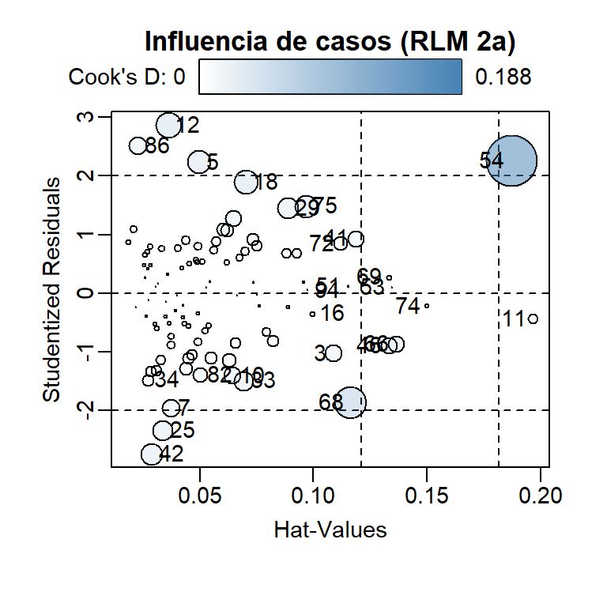

```r
par(cex = 0.9, mgp = c(1.75, 0.5, 0))
rlm2a_inf <- influencePlot(rlm2a_equiv, fill.col = "steelblue",
                           scale = 5, id = list(n = 15),
                           main = "Influencia de casos (RLM 2a)\n")
```

Ahora determinemos los umbrales a considerar para este modelo.

```r
n_casos2a <- nrow(rlm2a_df)           # Número de casos
p_rlm2a <- length(coef(rlm2a))        # Número de parámetros del modelo
gdl_rlm2a <- n_casos2a - p_rlm2a - 1  # Grados de libertad del modelo

lim_res_rlm2a <- abs(round(qt(0.05 / 2, df = gdl_rlm2a), 3))
lim_hat_rlm2a <- round(2 * mean(hatvalues(rlm2a)), 3)
lim_cook1_rlm2a <- round(mean(cooks.distance(rlm2a)) +
                         3 * sd(cooks.distance(rlm2a)), 3)
lim_cook2_rlm2a <- round(qf(0.5, df1 = p_rlm2a, df2 = n_casos2a - p_rlm2a), 3)

cat("Límites para el modelo de RLM 2:\n")
cat("Rango para 95% de los residuos studentizados: ")
cat("[", -lim_res_rlm2a, ", ", lim_res_rlm2a, "]\n", sep = "")
cat("Límite del apalancamiento:", lim_hat_rlm2a, "\n")
cat("Límite de sospecha para la distancia de Cook:", lim_cook1_rlm2a, "\n")
cat("Límite crítico para la distancia de Cook:", lim_cook2_rlm2a, "\n")
```

```
Límites para el modelo de RLM 2:
Rango para 95% de los residuos studentizados: [-1.986, 1.986]
Límite del apalancamiento: 0.121
Límite de sospecha para la distancia de Cook: 0.077
Límite crítico para la distancia de Cook: 0.898
```

E identifiquemos los casos que sobrepasan estos límites.

```r
rlm2a_inf_filtrados <- rlm2a_inf |>
  filter(abs(StudRes) > lim_res_rlm2a |
         Hat > lim_hat_rlm2a |
         CookD > lim_cook1_rlm2a)

cat("Casos notorios para el modelo de RML 2 alternativo:\n")
print(rlm2a_inf_filtrados)
```

```
Casos notorios para el modelo de RML 2 alternativo:
       StudRes        Hat        CookD
5   2.22988768 0.04975568 0.0416156683
11 -0.43228582 0.19682007 0.0076994754
12  2.86920717 0.03608159 0.0476532996
25 -2.33841039 0.03368474 0.0303127125
42 -2.74304143 0.02900557 0.0350051625
46 -0.89009556 0.13316781 0.0203309367
53  0.09893538 0.13461722 0.0002565035
54  2.26135020 0.18716037 0.1879298809
66 -0.86903522 0.13630394 0.0199166164
69  0.27454143 0.13324371 0.0019505347
74 -0.21946531 0.15009713 0.0014323575
86  2.51579153 0.02269816 0.0231718377
```

Solo el caso 54 muestra estadísticas de influencia preocupantes. Revisemos su impacto en el modelo.

```r
casos <- rownames(rlm2a_inf_filtrados)
id_casos <- which(casos == "54")
i_datos <- which(rownames(rlm2a_df) %in% casos[id_casos])

rlm2b <- update(rlm2a_equiv, data = rlm2a_df[-i_datos, ])

par(mgp = c(1.5, 0.5, 0), mfrow = c(1, 2))
invisible(mmp(rlm2a_equiv,
          col = "steelblue", pch = 20, col.line = c("steelblue", "red"),
          smooth = list(smoother = loessLine, span = 1),
          id = list(method = casos[id_casos], cex = 0.8, location = "lr"),
          main = "Relación marginal (RLM 2a)")
)
invisible(mmp(rlm2b,
          col = "steelblue", pch = 20, col.line = c("steelblue", "red"),
          smooth = list(smoother = loessLine, span = 1),
          id = list(n = 3, location = "lr", cex = 0.8),
          main = "Relación marginal (RLM 2b)")
)
```

[figure not shown]

Podemos ver que el caso 54, a pesar de tener estadísticas de influencia fuera de rango, en realidad no tiene una sobreinfluencia indebida en los coeficientes del modelo alternativo.

### Independencia de los residuos

Confirmemos que no existe dependencia entre los residuos generados por el modelo de RLM 2 obtenido.

```r
cat("Prueba de la independencia de los residuos para el modelo de RLM 2:\n")
print(durbinWatsonTest(rlm2a))
```

```
Prueba de la independencia de los residuos para el modelo de RLM 2:
 lag Autocorrelation D-W Statistic p-value
   1    -0.004056009      1.999522    0.94
 Alternative hypothesis: rho != 0
```

Vemos que no hay razones para rechazar la hipótesis de que los residuos de este modelo son independientes ($\small \text{D-W}=2{,}000$; $\small p=0{,}940$).

De esta forma, hemos revisado que el modelo de RLM 2 obtenido presenta un **buen ajuste** a los datos y **es confiable** (cumple las condiciones para usar modelos de regresión lineal y no hay evidencia de multicolinealidad, dependencia ni de la presencia de casos sobreinfluyentes).

### Desempeño

Veamos los niveles de error cometidos por el modelo de RLM 2 que hemos conseguido. Como antes, analizando un histograma de los errores (RMSE) en cada repetición, esta vez de la validación cruzada, además del reporte generado por la función `train()`.

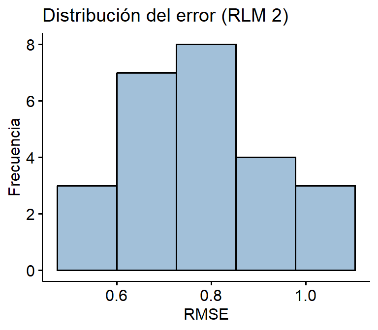

```r
rlm2_err_df <- data.frame(RMSE = rlm2a_train[["resample"]][["RMSE"]])
rlm2_err_p <- gghistogram(rlm2_err_df, x = "RMSE", bins = 5,
                          fill = "steelblue", ylab = "Frecuencia",
                          title = "Distribución del error (RLM 2)")
print(rlm2_err_p)
```

```r
cat("Rendimiento del modelo de RLM 2:\n")
print(rlm2_train[["results"]], digits = 3)
cat("\nMás detalle de la raíz del error cuadrático medio:\n")
print(describe(rlm2_err_df, trim = 0, quant = c(0.25, 0.75),
               skew = FALSE, IQR = TRUE), digits = 3)
```

```
Rendimiento del modelo de RLM 2:
  intercept  RMSE Rsquared   MAE RMSESD RsquaredSD  MAESD
1      TRUE 0.859    0.568 0.677  0.146      0.161 0.0881

Más detalle de la raíz del error cuadrático medio:
     vars  n  mean    sd median   min   max range    se   IQR Q0.25 Q0.75
RMSE    1 25 0.783 0.134  0.754 0.537 1.041 0.505 0.027 0.186 0.682 0.868
```

El modelo comete errores que van desde $\small 0{,}537$ y $\small 1{,}041$ cm ($\small 0{,}783 \pm 0{,}134$ cm en promedio). Este resultado **no es malo** si consideramos que la variable de respuesta varía entre $\small 16{,}0$ y $\small 21{,}6$ cm.

## Regresión logística múltiple usando RFE

La instrucción 5 nos pide usar RFE para conseguir un modelo de regresión logística múltiple (RLogitM) para predecir la variable `TRG`, que incluya de 4 a 12 predictores, utilizando validación cruzada dejando uno fuera para evitar el sobreajuste.

Esto podemos hacerlo con el siguiente código, que indica a la función `rfe()` que utilice la función `twoClassSummary()` para medir el rendimiento del modelo, la que calcula las métricas de sensibilidad, especificidad y área bajo la curva ROC. Nuevamente definimos una semilla para poder reproducir la validación cruzada y quitamos la variable numérica relacionada (`Knees.diameter`).

```r
rlogitm_df <- muestra_ext |> select(-all_of(respuesta_lineal))
fmla_completa <- formula(paste(respuesta_binaria, ".", sep = " ~ "))

lrFuncs[["summary"]] <- twoClassSummary
rlogitm_rfe_control <- rfeControl(functions = lrFuncs, method = "LOOCV",
                                  saveDetails = TRUE, returnResamp = "all",
                                  verbose = FALSE)
rlogitm_train_control <- trainControl(method = "none", classProbs = TRUE,
                                      summaryFunction = twoClassSummary)

# Semilla para garantizar reproducibilidad
set.seed(17 * 11111)

# Se suprimen los *warnings* puesto que muchas combinaciones podrían tener
# problemas para converger y la consola podría se llenarse con estos mensajes.
rlogitm_rfe <- suppressWarnings(
  rfe(fmla_completa, data = rlogitm_df, sizes = 4:12, metric = "ROC",
      rfeControl = rlogitm_rfe_control, trControl = rlogitm_train_control)
  )
rlogitm <- rlogitm_rfe[["fit"]]
```

Podemos visualizar el proceso de búsqueda realizado por la función `rfe()`.

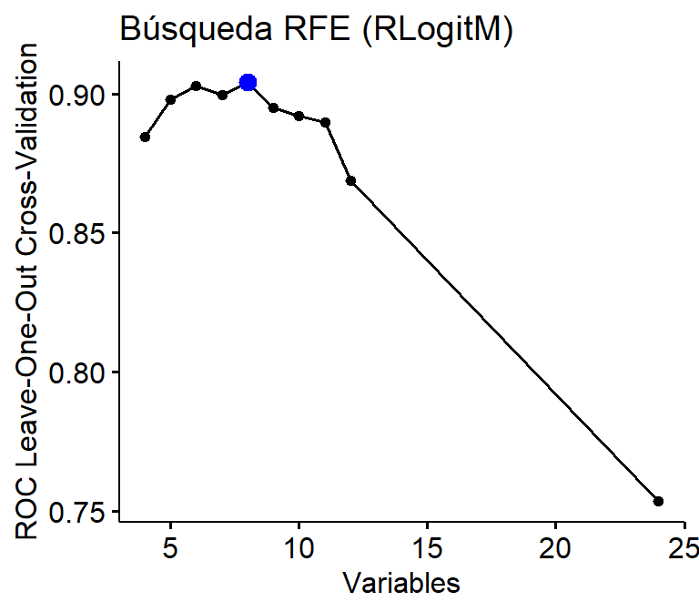

```r
rlogitm_rfe_p <- ggplot(rlogitm_rfe) + theme_pubr()
rlogitm_rfe_p <- ggpar(rlogitm_rfe_p, title = "Búsqueda RFE (RLogitM)")
print(rlogitm_rfe_p)
```

Notemos, mirando las etiquetas del gráfico, que usando la función `twoClassSummary()` para medir el rendimiento del modelo, la búsqueda de predictores intenta maximizar el área bajo la curva ROC obtenida.

Aprovechemos de observar que, por la naturaleza del método RFE que intenta ir descartando predictores, siempre se evalúa el modelo con todos los posibles predictores, que en este caso resulta con menor desempeño que usando de 4 a 12 variables. Si bien los mensajes de *warnings* que se generan por dificultades de convergencia pueden ser molestos, en general estos no son problemáticos a menos que este modelo inicial converja y obtenga el mejor resultado. En tal caso, la función `rfe()` retorna este modelo y hay que *bucear* en las opciones y el objeto que retorna para recuperar algún modelo con el tamaño requerido.

Veamos el modelo conseguido con el método RFE.

```r
cat("Modelo de RLogitM obtenido con RFE:\n")
print(summary(rlogitm))
```

```
Modelo de RLogitM obtenido con RFE:

Call:
glm(formula = Class ~ ., family = "binomial", data = tmp)

Coefficients:
                     Estimate Std. Error z value Pr(>|z|)
(Intercept)         -76.73312   17.18686  -4.465 8.02e-06 ***
Wrist.Minimum.Girth   1.58847    0.65240   2.435  0.01490 *
Ankle.Minimum.Girth  -0.40606    0.35982  -1.128  0.25911
Biiliac.diameter      0.23803    0.23381   1.018  0.30867
Bicep.Girth          -0.07452    0.15645  -0.476  0.63383
Ankles.diameter       2.25020    0.73370   3.067  0.00216 **
Navel.Girth          -0.13531    0.07424  -1.823  0.06837 .
Thigh.Girth           0.38292    0.11648   3.288  0.00101 **
Height                0.08112    0.06358   1.276  0.20201
---
Signif. codes:  0 '***' 0.001 '**' 0.01 '*' 0.05 '.' 0.1 ' ' 1

(Dispersion parameter for binomial family taken to be 1)

    Null deviance: 138.629  on 99  degrees of freedom
Residual deviance:  54.059  on 91  degrees of freedom
AIC: 72.059

Number of Fisher Scoring iterations: 7
```

Podemos ver que, por la misma naturaleza del método mencionada anteriormente, el modelo incluye varios predictores que no parecen aportar al ajuste del modelo. Para decidir de mejor forma, podemos solicitar a R que obtenga los modelos resultante de eliminar una de las variables y compararlos con el modelo original usando la prueba de la razón de verosimilitud. Pero para evitar incompatibilidades, vamos a trabajar con un modelo equivalente de tipo estándar.

```r
# Recrear la fórmula del modelo obtenido con rfe()
rfe_seleccion <- predictors(rlogitm)
rfe_sel_text <- paste(rfe_seleccion, collapse = " + ")
rfe_fmla <- formula(paste(respuesta_binaria, rfe_sel_text, sep = " ~ "))

# Crear modelo equivalente
rlogitm_equiv <- glm(rfe_fmla, data = rlogitm_df, family = binomial(link = "logit"))

# Evaluar modelos con un predictor menos
print(drop1(rlogitm_equiv, test = "LRT"))
```

```
Single term deletions

Model:
TRG ~ Wrist.Minimum.Girth + Ankle.Minimum.Girth + Biiliac.diameter +
    Bicep.Girth + Ankles.diameter + Navel.Girth + Thigh.Girth +
    Height
                    Df Deviance    AIC     LRT  Pr(>Chi)
<none>                   54.059 72.059
Wrist.Minimum.Girth  1   61.389 77.389  7.3298 0.0067821 **
Ankle.Minimum.Girth  1   55.569 71.569  1.5100 0.2191344
Biiliac.diameter     1   55.152 71.152  1.0922 0.2959908
Bicep.Girth          1   54.291 70.291  0.2317 0.6302636
Ankles.diameter      1   67.175 83.175 13.1155 0.0002929 ***
Navel.Girth          1   57.949 73.949  3.8892 0.0485990 *
Thigh.Girth          1   68.816 84.816 14.7563 0.0001223 ***
Height               1   55.753 71.753  1.6940 0.1930754
---
Signif. codes:  0 '***' 0.001 '**' 0.01 '*' 0.05 '.' 0.1 ' ' 1
```

Podemos observar que el modelo más parecido (esto es, que conlleva a una verosimilitud similar) se obtiene eliminando el predictor `Bicep.Girth` ($\small \chi^{2}=0{,}232$; $\small p=0{,}630$).

Actualicemos el modelo y reevaluemos los predictores.

```r
rlogitm_ajustado <- update(rlogitm_equiv, . ~ . - Bicep.Girth)

# Evaluar modelos con un predictor menos
print(drop1(rlogitm_ajustado, test = "LRT"))
```

```
Single term deletions

Model:
TRG ~ Wrist.Minimum.Girth + Ankle.Minimum.Girth + Biiliac.diameter +
    Ankles.diameter + Navel.Girth + Thigh.Girth + Height
                    Df Deviance    AIC     LRT  Pr(>Chi)
<none>                   54.291 70.291
Wrist.Minimum.Girth  1   63.214 77.214  8.9233 0.0028156 **
Ankle.Minimum.Girth  1   55.631 69.631  1.3400 0.2470428
Biiliac.diameter     1   55.666 69.666  1.3752 0.2409255
Ankles.diameter      1   67.268 81.268 12.9773 0.0003153 ***
Navel.Girth          1   59.082 73.082  4.7910 0.0286082 *
Thigh.Girth          1   68.903 82.903 14.6123 0.0001321 ***
Height               1   55.845 69.845  1.5536 0.2126038
---
Signif. codes:  0 '***' 0.001 '**' 0.01 '*' 0.05 '.' 0.1 ' ' 1
```

Podemos ver que ahora podemos eliminar el predictor `Ankle.Minimum.Girth` sin cambiar significativamente la verosimilitud del modelo ($\small \chi^{2}=1{,}340$; $\small p=0{,}247$). Actualizamos y reevaluemos el nuevo modelo.

```r
rlogitm_ajustado <- update(rlogitm_ajustado, . ~ . - Ankle.Minimum.Girth)

# Evaluar modelos con un predictor menos
print(drop1(rlogitm_ajustado, test = "LRT"))
```

```
Single term deletions

Model:
TRG ~ Wrist.Minimum.Girth + Biiliac.diameter + Ankles.diameter +
    Navel.Girth + Thigh.Girth + Height
                    Df Deviance    AIC     LRT  Pr(>Chi)
<none>                   55.631 69.631
Wrist.Minimum.Girth  1   63.229 75.229  7.5984 0.0058421 **
Biiliac.diameter     1   56.576 68.576  0.9446 0.3310980
Ankles.diameter      1   67.618 79.618 11.9871 0.0005357 ***
Navel.Girth          1   60.117 72.117  4.4862 0.0341696 *
Thigh.Girth          1   69.255 81.255 13.6239 0.0002233 ***
Height               1   57.940 69.940  2.3088 0.1286413
---
Signif. codes:  0 '***' 0.001 '**' 0.01 '*' 0.05 '.' 0.1 ' ' 1
```

Podemos hacer lo mismo con el predictor `Biiliac.diameter` ($\small \chi^{2}=0{,}945$; $\small p=0{,}331$).

```r
rlogitm_ajustado <- update(rlogitm_ajustado, . ~ . - Biiliac.diameter)

# Evaluar modelos con un predictor menos
print(drop1(rlogitm_ajustado, test = "LRT"))
```

```
Single term deletions

Model:
TRG ~ Wrist.Minimum.Girth + Ankles.diameter + Navel.Girth + Thigh.Girth +
    Height
                    Df Deviance    AIC     LRT  Pr(>Chi)
<none>                   56.576 68.576
Wrist.Minimum.Girth  1   63.402 73.402  6.8259 0.0089844 **
Ankles.diameter      1   68.435 78.435 11.8591 0.0005738 ***
Navel.Girth          1   60.193 70.193  3.6172 0.0571839 .
Thigh.Girth          1   70.446 80.446 13.8705 0.0001959 ***
Height               1   60.279 70.279  3.7035 0.0542973 .
---
Signif. codes:  0 '***' 0.001 '**' 0.01 '*' 0.05 '.' 0.1 ' ' 1
```

A pesar de estar cerca del borde de significanción, todavía tenemos evidencia que respaldaría la decisión de eliminar también el predictor `Navel.Girth` ($\small \chi^{2}=3{,}617$; $\small p=0{,}057$). Procedamos para obtener un modelo más parsimonioso.

```r
rlogitm_ajustado <- update(rlogitm_ajustado, . ~ . - Navel.Girth)

# Evaluar modelos con un predictor menos
print(drop1(rlogitm_ajustado, test = "LRT"))
```

```
Single term deletions

Model:
TRG ~ Wrist.Minimum.Girth + Ankles.diameter + Thigh.Girth + Height
                    Df Deviance    AIC     LRT Pr(>Chi)
<none>                   60.193 70.193
Wrist.Minimum.Girth  1   65.467 73.467  5.2736 0.021651 *
Ankles.diameter      1   68.659 76.659  8.4658 0.003619 **
Thigh.Girth          1   70.485 78.485 10.2919 0.001336 **
Height               1   64.345 72.345  4.1521 0.041582 *
---
Signif. codes:  0 '***' 0.001 '**' 0.01 '*' 0.05 '.' 0.1 ' ' 1
```

### Multicolinealidad

Revisemos los niveles de multicolinealidad del modelo ajustado.

```r
cat("Factores de inflación de la varianza:\n")
print(vif(rlogitm_ajustado))
cat("\n")
cat("Valores de tolerancia:\n")
print(1 / vif(rlogitm_ajustado))
```

```
Factores de inflación de la varianza:
Wrist.Minimum.Girth     Ankles.diameter         Thigh.Girth              Height
           1.341057            1.218451            1.368666            1.364814

Valores de tolerancia:
Wrist.Minimum.Girth     Ankles.diameter         Thigh.Girth              Height
          0.7456807           0.8207139           0.7306387           0.7327006
```

Apreciamos que todos los predictores presentan valores de inflación de la varianza bajos.

### Ajuste

Analicemos el ajuste del modelo conseguido y realicemos una comparación con el modelo más complejo y el modelo nulo.

```r
rlogitm_nulo_fmla <- formula(paste(respuesta_binaria, "1", sep = " ~ "))
rlogitm_nulo <- glm(rlogitm_nulo_fmla, data = rlogitm_df,
                    family = binomial(link = "logit"))

cat("Modelo de RLogitM con cuatro predictores:\n")
print(summary(rlogitm_ajustado))
cat("\n")
cat("Comparación con el modelo nulo:\n")
print(anova(rlogitm_nulo, rlogitm_ajustado, rlogitm_equiv, test = "LRT"))
```

```
Modelo de RLogitM con cuatro predictores:

Call:
glm(formula = TRG ~ Wrist.Minimum.Girth + Ankles.diameter + Thigh.Girth +
    Height, family = binomial(link = "logit"), data = rlogitm_df)

Coefficients:
                     Estimate Std. Error z value Pr(>|z|)
(Intercept)         -65.33697   14.15814  -4.615 3.93e-06 ***
Wrist.Minimum.Girth   0.91705    0.43195   2.123  0.03375 *
Ankles.diameter       1.43734    0.54716   2.627  0.00862 **
Thigh.Girth           0.21668    0.07403   2.927  0.00342 **
Height                0.10466    0.05438   1.925  0.05429 .
---
Signif. codes:  0 '***' 0.001 '**' 0.01 '*' 0.05 '.' 0.1 ' ' 1

(Dispersion parameter for binomial family taken to be 1)

    Null deviance: 138.629  on 99  degrees of freedom
Residual deviance:  60.193  on 95  degrees of freedom
AIC: 70.193

Number of Fisher Scoring iterations: 6


Comparación con el modelo nulo:
Analysis of Deviance Table

Model 1: TRG ~ 1
Model 2: TRG ~ Wrist.Minimum.Girth + Ankles.diameter + Thigh.Girth + Height
Model 3: TRG ~ Wrist.Minimum.Girth + Ankle.Minimum.Girth + Biiliac.diameter +
    Bicep.Girth + Ankles.diameter + Navel.Girth + Thigh.Girth +
    Height
  Resid. Df Resid. Dev Df Deviance  Pr(>Chi)
1        99    138.629
2        95     60.193  4   78.437 3.734e-16 ***
3        91     54.059  4    6.133    0.1894
---
Signif. codes:  0 '***' 0.001 '**' 0.01 '*' 0.05 '.' 0.1 ' ' 1
```

Observamos que el modelo consigue una reducción importante y significativa de la devianza ($\small \chi^{2}(4)=78{,}437, p\ll0{,}001$) respecto del modelo nulo. También, que el aporte del predictor `Height` no alcanza a ser significativo con el criterio de la prueba Z ($\small Z=1{,}925, p=0{,}054$) y confirmamos que su ajuste es similar al del modelo originalmente encontrado con el método RFE ($\small \chi^{2}(4)=6{,}133, p=0{,}189$).

### Relaciones lineales

Revisemos que se cumple la condición de relaciones lineales entre los predictores y la respuesta transformada, para lo que usaremos la función `crPlots()` del paquete `car`.

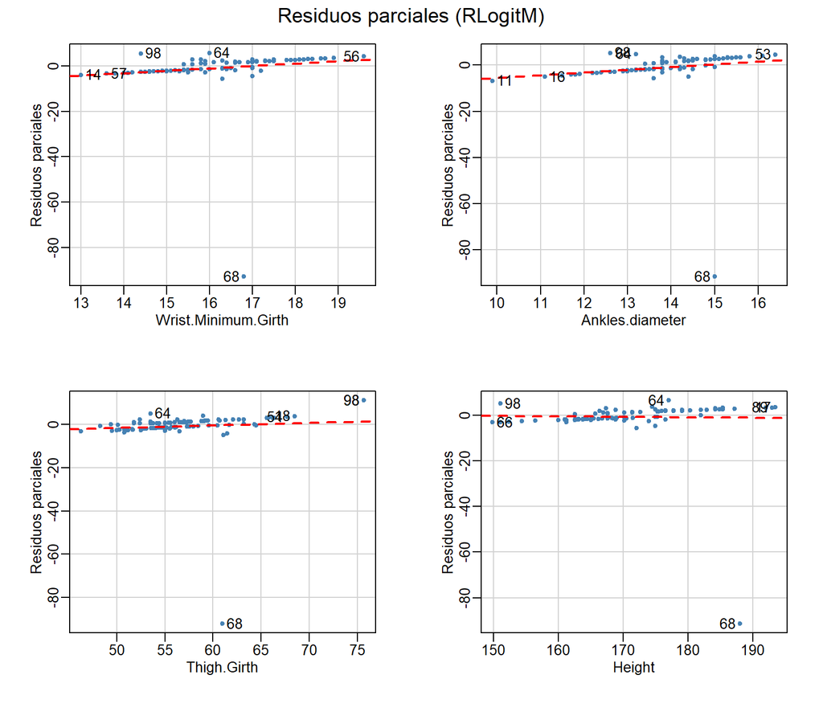

```r
par(mgp = c(1.5, 0.5, 0))
crPlots(rlogitm_ajustado, layout = c(2, 2),
        col = "steelblue", pch = 20, cex = 1.5, lty = 2, col.lines = "red",
        id = list(n = 3, cex = 1, location = "lr"),
        main = "Residuos parciales (RLogitM)",
        ylab = "Residuos parciales")
```

¡Uf! Hay un caso atípico que no deja ver bien los gráficos. Hagamos un “zoom”.

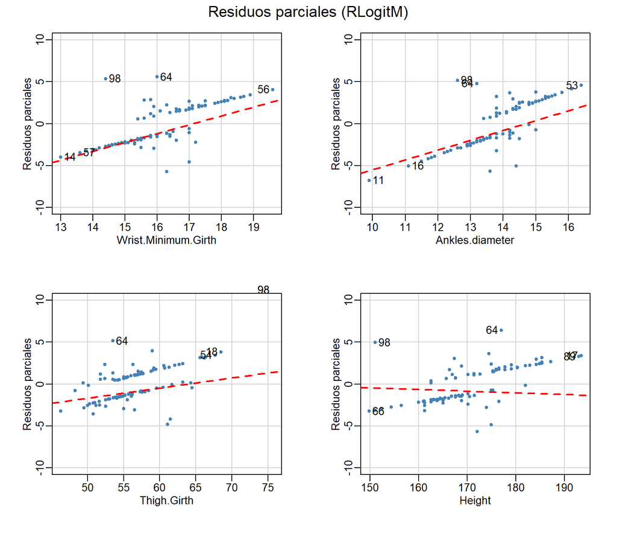

```r
par(mgp = c(1.5, 0.5, 0))
crPlots(rlogitm_ajustado, layout = c(2, 2),
        col = "steelblue", pch = 20, cex = 1.5, lty = 2,
        col.lines = "red", ylim = c(-10, 10),
        id = list(n = 3, cex = 1, location = "lr"),
        main = "Residuos parciales (RLogitM)",
        ylab = "Residuos parciales")
```

El caso atípico parece estar distorsionando el ajuste del modelo. Veamos que efecto tendría su eliminación.

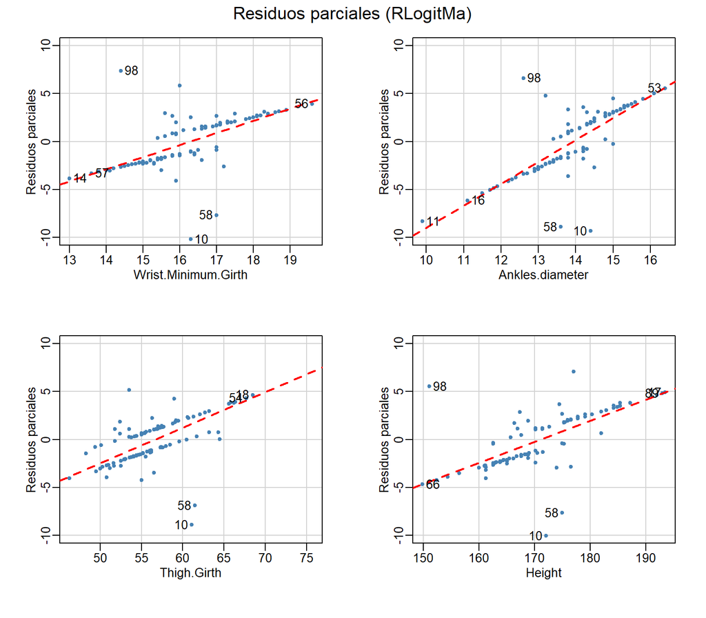

```r
i_quitar <- which(rownames(rlogitm_df) == "68")
rlogitma <- update(rlogitm_ajustado, data = rlogitm_df[-i_quitar, ])

par(mgp = c(1.5, 0.5, 0))
crPlots(rlogitma, layout = c(2, 2),
        col = "steelblue", pch = 20, cex = 1.5, lty = 2,
        col.lines = "red", ylim = c(-10, 10),
        id = list(n = 3, cex = 1, location = "lr"),
        main = "Residuos parciales (RLogitMa)",
        ylab = "Residuos parciales")
```

Podemos ver que todos los ajustes parciales mejoran. En este ajuste observamos que todas las relaciones de entre los predictores y la variable de salida transformada parecen lineales, actuando como *separadores* de las dos clases, sin que se vean patrones que se podrían atribuir a relaciones de otro tipo.

#### Reevaluación de la multicolinealidad.

Verificamos entonces que con la eliminación del caso atípico no hemos afectado la multicolinealidad entre los predictores.

```r
cat("Factores de inflación de la varianza:\n")
print(vif(rlogitma))
cat("\n")
cat("Valores de tolerancia:\n")
print(1 / vif(rlogitma))
```

```
Factores de inflación de la varianza:
Wrist.Minimum.Girth     Ankles.diameter         Thigh.Girth              Height
           1.321916            1.263012            1.657776            1.459659

Valores de tolerancia:
Wrist.Minimum.Girth     Ankles.diameter         Thigh.Girth              Height
          0.7564776           0.7917581           0.6032180           0.6850917
```

Se mantienen los indicadores de baja colinealidad.

#### Reevaluación del ajuste.

Revisemos el ajuste del nuevo modelo.

```r
rlogitm_nuloa <- glm(rlogitm_nulo_fmla, data = rlogitm_df[-i_quitar, ],
                     family = binomial(link = "logit"))

cat("Modelo de RLogitMa (sin caso atípico):\n")
print(summary(rlogitma))
cat("\n")
cat("Comparación con el modelo nulo:\n")
print(anova(rlogitm_nuloa, rlogitma, test = "LRT"))
```

```
Modelo de RLogitMa (sin caso atípico):

Call:
glm(formula = TRG ~ Wrist.Minimum.Girth + Ankles.diameter + Thigh.Girth +
    Height, family = binomial(link = "logit"), data = rlogitm_df[-i_quitar,
    ])

Coefficients:
                     Estimate Std. Error z value Pr(>|z|)
(Intercept)         -86.30226   18.95168  -4.554 5.27e-06 ***
Wrist.Minimum.Girth   0.87458    0.47327   1.848  0.06461 .
Ankles.diameter       1.82885    0.63793   2.867  0.00415 **
Thigh.Girth           0.29468    0.09081   3.245  0.00117 **
Height                0.17390    0.06673   2.606  0.00916 **
---
Signif. codes:  0 '***' 0.001 '**' 0.01 '*' 0.05 '.' 0.1 ' ' 1

(Dispersion parameter for binomial family taken to be 1)

    Null deviance: 137.233  on 98  degrees of freedom
Residual deviance:  49.366  on 94  degrees of freedom
AIC: 59.366

Number of Fisher Scoring iterations: 7


Comparación con el modelo nulo:
Analysis of Deviance Table

Model 1: TRG ~ 1
Model 2: TRG ~ Wrist.Minimum.Girth + Ankles.diameter + Thigh.Girth + Height
  Resid. Df Resid. Dev Df Deviance  Pr(>Chi)
1        98    137.233
2        94     49.366  4   87.867 < 2.2e-16 ***
---
Signif. codes:  0 '***' 0.001 '**' 0.01 '*' 0.05 '.' 0.1 ' ' 1
```

Como apreciamos de manera visual, sin el caso atípico el mismo conjunto de predictores conlleva a un modelo con menor devianza (49,366) que es significativamente menor en comparación al modelo nulo ($\small \chi^{4}=87{,}867$; $\small p \ll 0{,}001$). También podemos notar un cambio en la importancia de los predictores: `Wrist.Minimum.Girth` ya no parece aportar de manera significativa al ajuste conseguido mientras que `Height`ahora sí lo hace.

### Casos sobreinfluyentes

Confirmemos que no hay casos con sobreinfluencia en el modelo al haber eliminado el caso atípico más complicado.

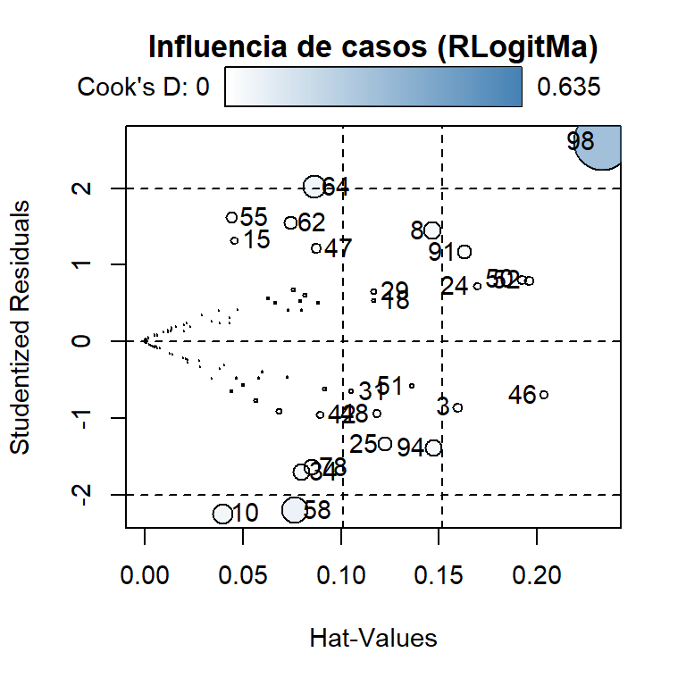

```r
par(cex = 0.9)
rlogitma_inf <- influencePlot(rlogitma,
                              fill.col = "steelblue",
                              scale = 5, id = list(n = 15),
                              main = "Influencia de casos (RLogitMa)\n")
```

Calculemos los umbrales para las estadísticas de influencia para este modelo.

```r
n_casosa <- nrow(rlogitm_df[-i_quitar, ])  # Número de casos
p_rlogitma <- length(coef(rlogitma))       # Número de parámetros del modelo
gdl_rlogitma <- n_casosa - p_rlogitma - 1  # Grados de libertad del modelo

lim_res_rlogitma <- abs(round(qt(0.05 / 2, df = gdl_rlogitma), 3))
lim_hat_rlogitma <- round(2 * mean(hatvalues(rlogitma)), 3)
lim_cook1_rlogitma <- round(mean(cooks.distance(rlogitma)) +
                            3 * sd(cooks.distance(rlogitma)), 3)
lim_cook2_rlogitma <- round(qf(0.5, df1 = p_rlogitma, df2 = n_casosa - p_rlogitma), 3)

cat("Límites para el modelo de RLogitMa:\n")
cat("Rango para 95% de los residuos studentizados: ")
cat("[", -lim_res_rlogitma, ", ", lim_res_rlogitma, "]\n", sep = "")
cat("Límite del apalancamiento:", lim_hat_rlogitma, "\n")
cat("Límite de sospecha para la distancia de Cook:", lim_cook1_rlogitma, "\n")
cat("Límite crítico para la distancia de Cook:", lim_cook2_rlogitma, "\n")
```

```
Límites para el modelo de RLogitMa:
Rango para 95% de los residuos studentizados: [-1.986, 1.986]
Límite del apalancamiento: 0.101
Límite de sospecha para la distancia de Cook: 0.215
Límite crítico para la distancia de Cook: 0.877
```

Ahora aplicamos los umbrales.

```r
rlogitma_inf_filtrados <- rlogitma_inf |>
  filter(abs(StudRes) > lim_res_rlogitma |
         Hat > lim_hat_rlogitma |
         CookD > lim_cook1_rlogitma)

cat("Casos notorios para el modelo de RLogitMa:\n")
print(rlogitma_inf_filtrados)
```

```
Casos notorios para el modelo de RLogitMa:
      StudRes        Hat       CookD
3  -0.8556816 0.15951691 0.017601334
8   1.4490212 0.14650160 0.060731860
10 -2.2437502 0.03993153 0.079968164
18  0.5322166 0.11658136 0.004225823
24  0.7227984 0.16937366 0.012963061
25 -1.3371760 0.12264256 0.039567091
29  0.6501021 0.11639742 0.006491552
31 -0.6525939 0.10502654 0.005804656
46 -0.7026051 0.20350603 0.015470119
48 -0.9403354 0.11826547 0.015341316
50  0.8101075 0.19184988 0.019643483
51 -0.5846543 0.13620369 0.006226181
52  0.7985352 0.19548518 0.019489275
58 -2.2025710 0.07653344 0.131794243
64  2.0207157 0.08638745 0.104807888
91  1.1702454 0.16298150 0.038588889
94 -1.3838055 0.14704661 0.053524077
98  2.6140509 0.23317995 0.635411394
```

Podemos apreciar que el caso 98, otra vez, tiene estadísticas de influencia preocupantes. Revisemos su efecto. El caso atípico parece estar distorsionando el ajuste del modelo. Veamos que efecto tendría su eliminación.

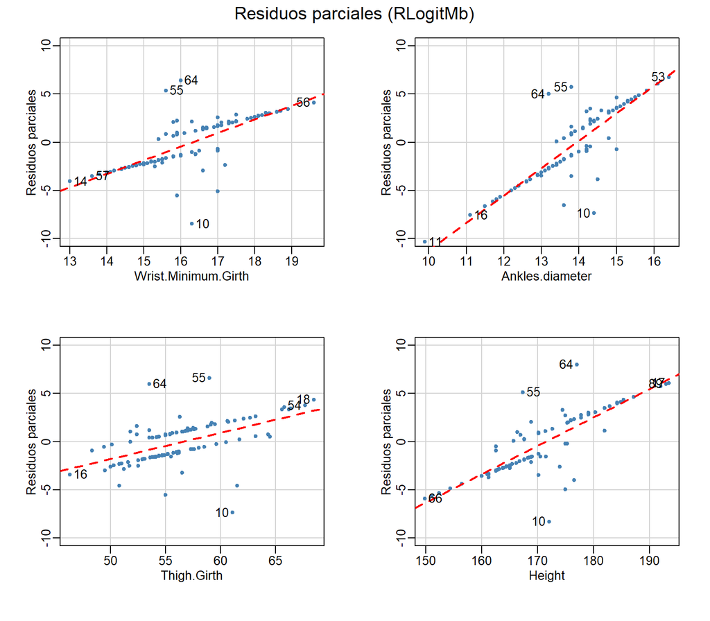

```r
i_quitar2 <- which(rownames(rlogitm_df) == "68" |
                   rownames(rlogitm_df) == "98")
rlogitmb <- update(rlogitm_ajustado, data = rlogitm_df[-i_quitar2, ])

par(mgp = c(1.5, 0.5, 0))
crPlots(rlogitmb, layout = c(2, 2),
        col = "steelblue", pch = 20, cex = 1.5, lty = 2,
        col.lines = "red", ylim = c(-10, 10),
        id = list(n = 3, cex = 1, location = "lr"),
        main = "Residuos parciales (RLogitMb)",
        ylab = "Residuos parciales")
```

Observamos que la condición de linealidad parece cumplirse bien para este nuevo modelo ajustado. Incluso, visualmente, se aprecia una mejora en el ajuste parcial del predictor `Thigh.Girth`, aunque no es claro que tenga un efecto muy relevante en las otras variables predictoras. Para comprobar podemos revisar los **dfBetas**, que miden **cuánto cambia** un coeficiente del modelo, expresado en errores estándar, al eliminar una observación particular. Entonces, podemos comparar las estadísticas descriptivas de los dfBetas para el conjunto de datos usados en el modelo y luego compararlo con los dfBetas específicos del caso sospechoso con etiqueta “98”.

```r
rlogitma_dfb <- dfbetas(rlogitma)
rlogitma_dfb_stats <- describe(rlogitma_dfb, quant = c(0.025, 0.975))
i_98 <- which(rownames(rlogitma_dfb) == "98")
caso_98_df <- data.frame(Valor = rlogitma_dfb[i_98, ])

cat("Estadísticas dfBetas del modelo de RLogitMa:\n")
print(rlogitma_dfb_stats[, c(3:5,8:10,14:15)], digits = 3)

cat("\nEstadísticas dfBetas del caso 98:\n")
print(caso_98_df, digits = 2)
```

```
Estadísticas dfBetas del modelo de RLogitMa:
                      mean    sd median    min   max range Q0.025 Q0.975
(Intercept)         -0.014 0.119 -0.025 -0.195 0.486 0.681 -0.168  0.364
Wrist.Minimum.Girth  0.007 0.139  0.002 -0.504 0.460 0.964 -0.316  0.379
Ankles.diameter      0.008 0.144  0.008 -0.614 0.414 1.027 -0.360  0.259
Thigh.Girth          0.009 0.160  0.014 -0.579 0.846 1.425 -0.410  0.227
Height               0.009 0.146  0.007 -0.599 0.418 1.017 -0.435  0.245

Estadísticas dfBetas del caso 98:
                     Valor
(Intercept)          0.404
Wrist.Minimum.Girth -0.046
Ankles.diameter     -0.517
Thigh.Girth          0.846
Height              -0.599
```

#### Reevaluación de la multicolinealidad.

Verificamos entonces que este nuevo modelo no afectadq la multicolinealidad entre los predictores.

```r
cat("Factores de inflación de la varianza:\n")
print(vif(rlogitmb))
cat("\n")
cat("Valores de tolerancia:\n")
print(1 / vif(rlogitmb))
```

```
Factores de inflación de la varianza:
Wrist.Minimum.Girth     Ankles.diameter         Thigh.Girth              Height
           1.138111            1.220802            1.338240            1.428847

Valores de tolerancia:
Wrist.Minimum.Girth     Ankles.diameter         Thigh.Girth              Height
          0.8786486           0.8191336           0.7472499           0.6998648
```

Confirmamos que se mantienen los bajos valores de la inflación de la varianza.

#### Reevaluación del ajuste.

Revisemos el ajuste que se ha conseguido.

```r
rlogitm_nulob <- glm(rlogitm_nulo_fmla, data = rlogitm_df[-i_quitar2, ],
                     family = binomial(link = "logit"))

cat("Modelo de RLogitMb (sin dos casos atípicos):\n")
print(summary(rlogitmb))
cat("\n")
cat("Comparación con el modelo nulo:\n")
print(anova(rlogitm_nulob, rlogitmb, test = "LRT"))
```

```
Modelo de RLogitMb (sin dos casos atípicos):

Call:
glm(formula = TRG ~ Wrist.Minimum.Girth + Ankles.diameter + Thigh.Girth +
    Height, family = binomial(link = "logit"), data = rlogitm_df[-i_quitar2,
    ])

Coefficients:
                     Estimate Std. Error z value Pr(>|z|)
(Intercept)         -100.5626    23.2427  -4.327 1.51e-05 ***
Wrist.Minimum.Girth    0.9341     0.5200   1.796  0.07244 .
Ankles.diameter        2.3215     0.7597   3.056  0.00225 **
Thigh.Girth            0.2375     0.0879   2.702  0.00688 **
Height                 0.2290     0.0817   2.803  0.00507 **
---
Signif. codes:  0 '***' 0.001 '**' 0.01 '*' 0.05 '.' 0.1 ' ' 1

(Dispersion parameter for binomial family taken to be 1)

    Null deviance: 135.857  on 97  degrees of freedom
Residual deviance:  42.304  on 93  degrees of freedom
AIC: 52.304

Number of Fisher Scoring iterations: 7


Comparación con el modelo nulo:
Analysis of Deviance Table

Model 1: TRG ~ 1
Model 2: TRG ~ Wrist.Minimum.Girth + Ankles.diameter + Thigh.Girth + Height
  Resid. Df Resid. Dev Df Deviance  Pr(>Chi)
1        97    135.857
2        93     42.304  4   93.553 < 2.2e-16 ***
---
Signif. codes:  0 '***' 0.001 '**' 0.01 '*' 0.05 '.' 0.1 ' ' 1
```

Vemos que con el mismo conjunto de predictores, pero quitando dos casos atípicos que ejercían sobreinfluencia, conseguimos una disminución de la devianza (a 42,304) que es significativamente menor en comparación al modelo nulo ($\small \chi^{4}=93{,}553$; $\small p \ll 0{,}001$).

#### Reevaluación de casos sobreinfluyentes

Revisemos que no queden casos con sobreinfluencia en el modelo al haber eliminado el caso atípico más complicado.

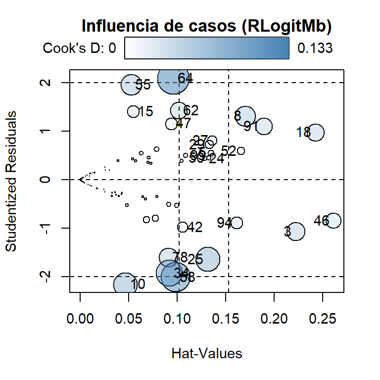

```r
par(cex = 0.9)
rlogitmb_inf <- influencePlot(rlogitmb, fill.col = "steelblue",
                              scale = 5, id = list(n = 15),
                              main = "Influencia de casos (RLogitMb)\n")
```

Calculemos los umbrales de sobreinfluencia para este nuevo modelo.

```r
n_casosb <- nrow(rlogitm_df[-i_quitar2, ])  # Número de casos
p_rlogitmb <- length(coef(rlogitmb))        # Número de parámetros del modelo
gdl_rlogitmb <- n_casosb - p_rlogitmb - 1   # Grados de libertad del modelo

lim_res_rlogitmb <- abs(round(qt(0.05 / 2, df = gdl_rlogitmb), 3))
lim_hat_rlogitmb <- round(2 * mean(hatvalues(rlogitmb)), 3)
lim_cook1_rlogitmb <- round(mean(cooks.distance(rlogitmb)) +
                            3 * sd(cooks.distance(rlogitmb)), 3)
lim_cook2_rlogitmb <- round(qf(0.5, df1 = p_rlogitmb,
                               df2 = n_casosb - p_rlogitmb), 3)

cat("Límites para el modelo de RLogitMb:\n")
cat("Rango para 95% de los residuos studentizados: ")
cat("[", -lim_res_rlogitmb, ", ", lim_res_rlogitmb, "]\n", sep = "")
cat("Límite del apalancamiento:", lim_hat_rlogitmb, "\n")
cat("Límite de sospecha para la distancia de Cook:", lim_cook1_rlogitmb, "\n")
cat("Límite crítico para la distancia de Cook:", lim_cook2_rlogitmb, "\n")
```

```
Límites para el modelo de RLogitMb:
Rango para 95% de los residuos studentizados: [-1.986, 1.986]
Límite del apalancamiento: 0.102
Límite de sospecha para la distancia de Cook: 0.085
Límite crítico para la distancia de Cook: 0.877
```

Ahora aplicamos los umbrales.

```r
rlogitmb_inf_filtrados <- rlogitmb_inf |>
  filter(abs(StudRes) > lim_res_rlogitmb |
         Hat > lim_hat_rlogitmb |
         CookD > lim_cook1_rlogitmb)

cat("Casos notorios para el modelo de RLogitMb:\n")
print(rlogitmb_inf_filtrados)
```

```
Casos notorios para el modelo de RLogitMb:
      StudRes        Hat       CookD
3  -1.0669852 0.22232038 0.045406825
5   0.5603834 0.13443289 0.005595846
8   1.3141957 0.17049360 0.055247832
10 -2.1548570 0.04676323 0.077027593
18  0.9787301 0.24269586 0.041640822
24  0.4452834 0.12844107 0.003260114
25 -1.6388437 0.13137886 0.077821268
27  0.8067306 0.13635127 0.012692599
29  0.7262780 0.13318077 0.009735035
34 -1.9266592 0.09203484 0.093270449
42 -0.9801522 0.10569483 0.014898486
46 -0.8424777 0.26119801 0.032759573
50  0.4490872 0.13239671 0.003442828
52  0.5925811 0.16561640 0.008173065
58 -2.0096400 0.09828802 0.116033191
64  2.0976698 0.09593595 0.133296371
91  1.1034265 0.18894623 0.039936976
94 -0.8856224 0.16124751 0.019318305
99  0.5052594 0.10865104 0.003483461
```

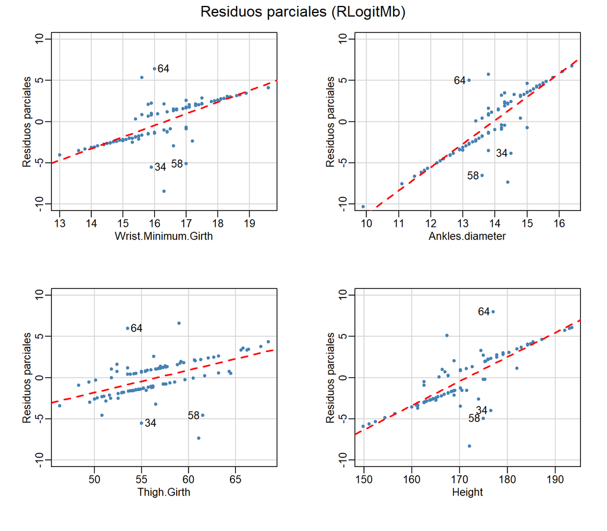

```r
casos <- rownames(rlogitmb[["data"]])
id <- which(casos == "34" | casos == "58" | casos == "64")

par(mgp = c(1.5, 0.5, 0))
crPlots(rlogitmb, layout = c(2, 2),
        col = "steelblue", pch = 20, cex = 1.5, lty = 2,
        col.lines = "red", ylim = c(-10, 10),
        id = list(method = casos[id], cex = 1, location = "lr"),
        main = "Residuos parciales (RLogitMb)",
        ylab = "Residuos parciales")
```

Podemos notar que, si bien estos casos están alejados de la nube de puntos, aparecen en el rango medio de los valores de los predictores por lo que su influencia es menor, y por encima y debajo del modelo, compensando el efecto que pudieran tener. De esta forma, podemos descartar que existan casos con una influencia exesiva en el modelo obtenido luego de quitar dos casos atípicos.

### Independencia de los residuos

Confirmemos que el modelo de RLogitM conseguido no genera dependencia en los residuos.

```r
cat("Prueba de la independencia de los residuos para el modelo de RLogitMb:\n")
print(durbinWatsonTest(rlogitmb))
```

```
Prueba de la independencia de los residuos para el modelo de RLogitMb:
 lag Autocorrelation D-W Statistic p-value
   1     -0.02339794      2.042951   0.848
 Alternative hypothesis: rho != 0
```

¡Bien! No hay evidencia de problemas con la independencia de los residuos de este modelo ($\small \text{D-W}=2{,}043$; $\small p=0{,}848$).

### Desempeño

El enunciado nos solicita evaluar el desempeño del modelo mediante el método de **validación cruzada dejando uno fuera** para evitar o detectar el sobreajuste. Si bien utilizamos este método para seleccionar los predictores más prometedores, como hemos ido cambiando los modelos de tipo base, el entrenamiento realizado al aplicar la función `rfe()` no corresponde al del modelo actual, por lo que debemos reconstruir uno equivalente con las funciones del paquete `caret` para obtener las estadísticas de desempeño de la forma solicitada.

```r
rlogitm_fmla <- formula(rlogitmb)
rlogitm_datos <- rlogitmb[["data"]]
rlogitm_trc <- trainControl(method = "LOOCV", classProbs = TRUE,
                            summaryFunction = twoClassSummary)

set.seed(17 * 11111)
rlogitm_tr <- train(rlogitm_fmla, data = rlogitm_datos,
                    method = "glm", metric = "ROC",
                    trControl = rlogitm_trc)
rlogitm <- rlogitm_tr[["finalModel"]]
```

Recordemos que el método de validación cruzada dejando uno fuera evalúa solo una observación en cada iteración. Por lo tanto, al concluir las iteraciones, solo se tiene una tabla de confusión de donde calcular las métricas de desempeño, es decir, no hay varias estimaciones del rendimiento del modelo como teníamos en las preguntas anteriores. Podemos conocer el desempeño del modelo de forma directa.

```r
cat("Rendimiento del modelo de RLogitMb (estimada con LOOCV):\n")
print(rlogitm_tr[["results"]][, 2:4], digits = 3)
```

```
Rendimiento del modelo de RLogitMb (estimada con LOOCV):
    ROC  Sens  Spec
1 0.956 0.898 0.857
```

Vemos que el modelo obtenido tiene un rendimiento bastante bueno, con un área bajo la curva ROC de $\small 0{,}956$ (sensibilidad = $\small 0{,}898$, especificidad = $\small 0{,}857$).

Por supuesto podemos tener más detalles de estos resultados mirando, por ejemplo, la matriz de confusión resultante.

```r
rlogitm_mat_conf <- confusionMatrix(rlogitm_tr[["pred"]][["pred"]],
                                    rlogitm_tr[["pred"]][["obs"]])

cat("Matriz de confusión del modelo de RLogitM:\n")
print(rlogitm_mat_conf, digit = 3)
```

```
Matriz de confusión del modelo de RLogitM:
Confusion Matrix and Statistics

          Reference
Prediction no sí
        no 44  7
        sí  5 42

               Accuracy : 0.878
                 95% CI : (0.796, 0.935)
    No Information Rate : 0.5
    P-Value [Acc > NIR] : 2.97e-15

                  Kappa : 0.755

 Mcnemar's Test P-Value : 0.773

            Sensitivity : 0.898
            Specificity : 0.857
         Pos Pred Value : 0.863
         Neg Pred Value : 0.894
             Prevalence : 0.500
         Detection Rate : 0.449
   Detection Prevalence : 0.520
      Balanced Accuracy : 0.878

       'Positive' Class : no
```

También podemos obtener una gráfica de la curva ROC conseguida.

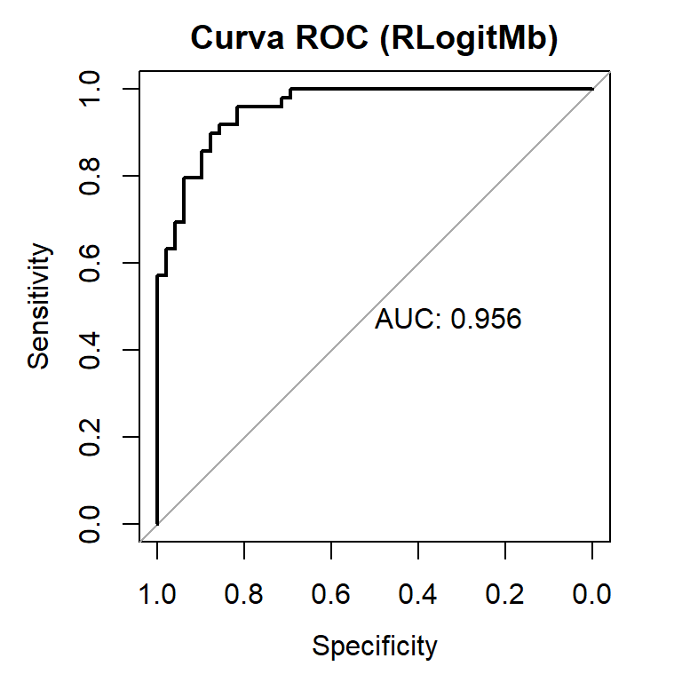

```r
rlogitm_roc <-roc(rlogitm_tr[["pred"]][["obs"]],
                  rlogitm_tr[["pred"]][["sí"]],
                  direction = "<", levels=c("no", "sí"))
plot(rlogitm_roc, print.auc = TRUE,
     main = "Curva ROC (RLogitMb)")
```

## Conclusión

La instrucción 6 del enunciado nos solicita que nos pronunciemos sobre la confiabilidad y la calidad predictiva de los modelos obtenidos. Veamos.

Los tres modelos son confiables en términos de ajuste, generando residuos sin patrones y sin indicios de falta de independencia o que no se cumpla la linealidad de las relaciones entre predictores y la variable de respuesta. En el caso de los modelos de RLM, además, no se halló evidencia para dudar que se cumple la normalidad y homocedasticidad de los residuos. Además, los tres modelos consiguen niveles aceptables de multicolinealidad.

Sin embargo, por el mínimo de variables predictoras solicitado en el enunciado, el segundo modelo de RLM incluye un predictor que no aporta al buen ajuste alcanzado. También fue necesario eliminar una observación atípica de este modelo y un par de observaciones con demasiada influencia del modelo de RLogitM que alteraban de forma indebida los coeficientes.

Los modelos de RLM consiguieron una calidad predictiva relativamente buena, aunque el modelo obtenido con RFE exhibe mayor error ($\small 0{,}859 \pm 0{,}146$ cm) que el modelo obtenido con el método de todos los subconjuntos ($\small 0{,}689 \pm 0{,}080$ cm), aunque el primero fue evaluado en 25 conjuntos de datos mientras que el segundo en casi 2.000, por lo que esta comparación no es completamente definitiva.

El modelo de RLogitM consiguió una muy buena calidad predictiva para detectar rodillas gruesas, alcanzando un área bajo la curva ROC sobre $\small 0{,}92$ estimada con validación cruzada dejando uno fuera.

## Declaración importante

Es importante notar que no hemos sido *atarantados* al minuto de remover datos al construir los modelos. De hecho, uno **no elimina simultáneamente** todos los casos sospechosos. Metodológicamente, uno tendría que eliminar **un caso** sobreinfluyente solo si se llega a la conclusión de que se trata de un **dato erróneo** o de **una excepción** en la **población (no la muestra)** que no se debería incluir en un modelo que pretende describir un fenómeno general. Si no es un error, una excepción o no se busca un modelo que describa la mayoría de la población, entonces el dato **no debe ser eliminado**.

Además, luego de eliminar un dato, se **debe revisar** el efecto que esto tuvo en el modelo, cómo cambiaron los coeficientes y el ajuste, y volver a examinar si aparecen otros casos sobreinfluyentes. Por razones pedagógicas (evitar complejizar demasiado el ejemplo) no hemos seguido exactamente este procedimiento en este script.

Es probable que en la vida laboral, algún “jefe/a” nos pida “*quitar algunos datitos*” (¡o variables!) de un modelo. Manipular los datos para conseguir un modelo que confirme lo que nos gustaría concluir es **profundamente antiético** y ningún profesional, menos uno de la Universidad de Santiago de Chile, debería cometer este tal acto deshonesto.

Por supuesto, como todo dilema moral, esto es más fácil decirlo que hacerlo cuando la estabilidad laboral está en juego. Cada estudiante debe prepararse para estas situaciones, aprovechando al máximo las instancias y asignaturas que apuntan a desarrollar y mejorar sus habilidades personales (y que a veces desatendemos por no comprender la relevancia que tienen).

## Referencias

Heinz, G., Peterson, L. J., Johnson, R. W., & Kerk, C. J. (2003). Exploring relationships in body dimensions. Journal of Statistics Education, 11(2).